```python
# @title Import packages
from pathlib import Path
import json
import requests
import os
import numpy as np
import matplotlib.pyplot as plt
import seaborn as sns
import pandas as pd
```

# Definition of variables in Behavior data

Variables inside `beh`:

- `beh['ntrials']`: number of trials
- `beh['trInd']`: trials index
- `beh['trInd_odd']`: the index of odd trials
- `beh['trInd_even']`: the index of even trials
- `beh['Trial_start_time']`: time when animal enters each corridor
- `beh['Trial_end_time']`: time when animal ran out each corridor
- `beh['stim_id']`: ID of stimuli; 0:circle1, 1:circle2, 2:leaf1, 3:leaf2 4:leaf3, 5:leaf1_swap1, 6:leaf1_swap2
- `beh['SubjMove']`: running information
  - `beh['SubjMove']['SubjMTime']`: time stamps of running
  - `beh['SubjMove']['SubjMPos']`: position inside corridor
  - `beh['SubjMove']['SubjMPosCum']`: cumulative position inside VR
  - `beh['SubjMove']['SubjMDistCum']`: almost identical with `beh['SubjMove']['SubjMPosCum']`
  - `beh['SubjMove']['SubjM_pitch']`: pitch (forward) running speed
  - `beh['SubjMove']['SubjM_roll']`: roll direction running speed
  - `beh['SubjMove']['SubjM_yaw']`: yaw direction running speed
  - `beh['SubjMove']['SubjM_pitch_cum']`: total running distance. Note that it is not the same as `beh['SubjMove']['SubjMPosCum']` given that we only move the VR and with a constant speed when `beh['SubjMove']['SubjM_pitch']` pass a threshold
- `beh['Gray_space_time']`: time when animal entered the gray space
- `beh['SoundPos']`: position of sound cue
- `beh['SoundTime']`: time of sound cue
- `beh['SoundTimeDelay']`: time of sound cue with a delay, if delay=0, then it is the same as `beh['SoundTime']`
- `beh['RewTime']`: time of reward delivery, these numbers only valid in the reward corridor.
- `beh['RewPos']`: position of reward delivery, with NaN in the non-reward corridor.
- `beh['isRew']`: boolean value indicating if the trial is a reward trial.
- `beh['WallType']`: category of stimuli, but please ignore this one since it doesn't apply to our experiments
- `beh['WallIsProbe']`: whether is a catch trial, but please ignore this one
- `beh['WallName']`: name of stimuli in each corridor
- `beh['UniqWalls']`: name of stimuli in the whole session
- `beh['LickTrind']`: trial stamp of each lick
- `beh['LickTime']`: time stamp of each lick
- `beh['LickPos']`: positional stamp of each lick
- `beh['Lick_wallName']`: corresponding stimulus of each lick
- `beh['VRpos']`: position inside VR
- `beh['VRposCum']`: cumulative position inside VR
- `beh['VRposTime']`: time stamp for `beh['VRpos']` and `beh['VRposCum']`
- `beh['ft']`: time stamp for each neural frame
- `beh['ft_trInd']`: trial stamp for each neural frame, NaN means outside the behavior recorded
- `beh['ft_trInd_odd']`: neural frames from odd trials
- `beh['ft_trInd_even']`: neural frames from even trials
- `beh['ft_Pos']`: position inside VR for each neural frame
- `beh['ft_PosCum']`: culculative position inside VR for each neural frame
- `beh['ft_move']`: the differences between each frame of `beh['ft_PosCum']`
- `beh['ft_isMoving']`: boolean value for `beh['ft_move']>0`
- `beh['ft_GraySpc']`: boolean value indicating if animals is inside gray space
- `beh['ft_CorrSpc']`: boolean value indicating if animals is inside texture area
- `beh['ft_WallID']`: the corridor each neural frame belongs to
- `beh['ft_RunCum']`: cumulative running distance for each neural frame
- `beh['ft_RunSpeed']`: running speed for each neural frame
- `beh['RunFr']`: same as `beh['ft_RunSpeed']`
- `beh['run_pos']`: running speed interpolated into trials * positions
- `beh['RewardFr']`: neural frame when reward was delivered, length=ntrials, NaN means trial without reward being delivered
- `beh['StartFr']`: neural frame when animal enter each corridor
- `beh['GrayFr']`: neural frame when animal enter gray space
- `beh['EndFr']`: neural frame when animal ran out of a corridor
- `beh['LickFr']`: neural frame when animal licked
- `beh['SoundFr']`: neural frame when sound cue was delivered
- `beh['SoundDelayFr']`: neural frame when sound cue was delivered + a delay, if delay=0, then it is the same as `beh['SoundFr']`
- `beh['SoundDelPos']`: position inside a corridor, corresponding to `beh['SoundDelayFr']`
- `beh['BefCueFr']`: boolean values indicating neural frames after entered corridor but before cue was delivered
- `beh['AftCueFr']`: boolean values indicating neural frames after cue was delivered
- `beh['TrialStim']`: stimulus name of each trial
- `beh['StimTrial']`: subfields are trial index of each stimulus
- `beh['StimFrame']`: subfields are neural frame index of each stimulus

Below are some settings:

- `beh['Corridor_Length']`: length of the corridor
- `beh['Gray_Space_length']`: length of gray space
- `beh['Texture_Length']`: length of texture area
- `beh['Reward_Mode']`: reward mode of experiment, either passive reward in which reward was delivered without lick or active reward in which reward was triggered be licking
- `beh['Reward_Delay_ms']`: delay time for reward, this is a setting. Find the actually reward time in `beh['RewTime']`

```python
# @title Print ALL Potential Data Files

import os
import numpy as np

# === Setup ===
root = '/content/Zhong_et_al_2025/'
neural_dir = os.path.join(root, 'neural_data')
os.makedirs(neural_dir, exist_ok=True)

data_root = '/content/Zhong_et_al_2025/neural_data'


print("📂 Available .npy files:")
for fname in os.listdir(data_root):
    if fname.endswith('.npy'):
        print(fname)


import requests
import json

ARTICLE_ID = 28811129
FIGSHARE_API = "https://api.figshare.com/v2"

r = requests.get(f"{FIGSHARE_API}/articles/{ARTICLE_ID}")
file_list = r.json()['files']

print("📥 Remote files on Figshare:")
for f in file_list:
    if f['name'].endswith('.npy'):
        print("  -", f['name'])
```

```
📂 Available .npy files:
📥 Remote files on Figshare:
  - Beh_naive_test1.npy
  - Beh_naive_test2.npy
  - Beh_naive_test3.npy
  - Beh_sup_test1.npy
  - Beh_sup_test2.npy
  - Beh_sup_test3.npy
  - Beh_sup_train1_after_learning.npy
  - Beh_sup_train1_before_learning.npy
  - Beh_sup_train2_after_learning.npy
  - Beh_sup_train2_before_learning.npy
  - Beh_test1_after_grating.npy
  - Beh_test1_before_grating.npy
  - Beh_test2_after_grating.npy
  - Beh_test2_before_grating.npy
  - Beh_train1_after_grating.npy
  - Beh_train1_before_grating.npy
  - Beh_unsup_test1.npy
  - Beh_unsup_test2.npy
  - Beh_unsup_test3.npy
  - Beh_unsup_train1_after_learning.npy
  - Beh_unsup_train1_before_learning.npy
  - Beh_unsup_train2_after_learning.npy
  - Beh_unsup_train2_before_learning.npy
  - example_bef_and_aft_learning_behavior.npy
  - Imaging_Exp_info.npy
  - Beh_no_pretrain.npy
  - Beh_pretrain_on_grat_image.npy
  - Beh_pretrain_on_nat_image.npy
  - DR10_2022_07_12_1_neural_data.npy
  - DR10_2022_07_19_1_neural_data.npy
  - DR10_2022_07_21_1_neural_data.npy
  - DR10_2022_07_28_1_neural_data.npy
  - DR10_2022_07_29_1_neural_data.npy
  - DR10_2022_07_30_1_neural_data.npy
  - DR15_2022_10_09_1_neural_data.npy
  - DR15_2022_10_19_1_neural_data.npy
  - DR15_2022_10_20_1_neural_data.npy
  - DR15_2022_11_02_1_neural_data.npy
```

[output cut: 154 more lines]

```
  - TX109_2023_03_16_1_SVD_dec.npy
  - TX88_2022_07_22_1_SVD_dec.npy
  - TX109_2023_04_07_1_SVD_dec.npy
  - VR2_2021_04_28_1_SVD_dec.npy
  - TX85_2022_06_17_1_SVD_dec.npy
  - TX61_2021_06_20_1_SVD_dec.npy
  - TX88_2022_06_20_1_SVD_dec.npy
  - VR2_2021_04_06_1_SVD_dec.npy
  - TX61_2021_06_23_1_SVD_dec.npy
  - TX88_2022_07_19_1_SVD_dec.npy
  - VR2_2021_04_29_1_SVD_dec.npy
  - TX61_2021_06_25_1_SVD_dec.npy
  - VR2_2021_05_06_1_SVD_dec.npy
  - VR2_2021_03_20_1_SVD_dec.npy
  - VR2_2021_04_11_1_SVD_dec.npy
```

```python
# @title === Download Behavior Data ===
import os
import json
import requests
from pathlib import Path

root = r'/content/Zhong_et_al_2025'
Path(root).mkdir(exist_ok=True)

# === Supervised mice only ===
sup_bef = 'VR2_2021_03_20_1'  # Before learning
sup_aft = 'VR2_2021_04_06_1'  # After learning

file_ID = [
    54866153,  # VR2_2021_03_20_1_example_raw_spk.npy
    54866354,  # VR2_2021_03_20_1_SVD_dec.npy
    54184211,  # VR2_2021_03_20_trans.npz
    54866333,  # VR2_2021_04_06_1_SVD_dec.npy
    54184214,  # VR2_2021_04_06_trans.npz
    54183863,  # Beh_sup_train1_before_learning.npy
    54183860   # Beh_sup_train1_after_learning.npy
]

# === Figshare API setup ===
BASE_URL = 'https://api.figshare.com/v2'
r = requests.get(BASE_URL + '/articles/28811129') # article ID
file_metadata = json.loads(r.text)

# === Download only supervised files ===
for file in file_metadata['files']:
    if file['id'] in file_ID:
        fn = os.path.join(root, file['name'])
        if not os.path.isfile(fn):
            print(f"⬇️ Downloading {file['name']}...")
            response = requests.get(BASE_URL + '/file/download/' + str(file['id']))
            with open(fn, 'wb') as f:
                f.write(response.content)
        else:
            print(f"✅ Already exists: {file['name']}")


# Function For getting additional data
def download_npy_from_figshare(root, target_file, article_id=28811129):
    """
    Download a .npy file from Figshare to the specified root directory.

    Args:
        root (str): Directory where the file should be saved.
        target_file (str): Name of the .npy file to download (must match Figshare listing).
        article_id (int): Figshare article ID (default is Zhong et al., 2025: 28811129).

    Returns:
        str: Local file path to the downloaded file.
    """
    os.makedirs(root, exist_ok=True)
    FIGSHARE_API = "https://api.figshare.com/v2"

    # Get file list from Figshare
    response = requests.get(f"{FIGSHARE_API}/articles/{article_id}")
    file_list = response.json()['files']

    # Search for the target file
    file_url = None
    for f in file_list:
        if f['name'] == target_file:
            file_url = f['download_url']
            break

    if file_url is None:
        raise FileNotFoundError(f"❌ {target_file} not found in Figshare article {article_id}.")

    # Download the file
    save_path = os.path.join(root, target_file)
    if not os.path.exists(save_path):  # Avoid re-downloading if already present
        print(f"⬇️ Downloading {target_file} ...")
        r = requests.get(file_url)
        with open(save_path, 'wb') as f:
            f.write(r.content)
        print(f"✅ Downloaded and saved to {save_path}")
    else:
        print(f"✔️ File already exists locally: {save_path}")

    return save_path

'''
# === Select Additional Files to Download  ===
root = "/content/Zhong_et_al_2025/neural_data"
target_file = "Imaging_Exp_info.npy" # Change THIS variable to name of file that you want to download
downloaded_path = download_npy_from_figshare(root, target_file)
'''
```

```
⬇️ Downloading Beh_sup_train1_after_learning.npy...
⬇️ Downloading Beh_sup_train1_before_learning.npy...
⬇️ Downloading VR2_2021_03_20_trans.npz...
⬇️ Downloading VR2_2021_04_06_trans.npz...
⬇️ Downloading VR2_2021_03_20_1_example_raw_spk.npy...
⬇️ Downloading VR2_2021_04_06_1_SVD_dec.npy...
⬇️ Downloading VR2_2021_03_20_1_SVD_dec.npy...
```

```
'\n# === Select Additional Files to Download  ===\nroot = "/content/Zhong_et_al_2025/neural_data"\ntarget_file = "Imaging_Exp_info.npy" # Change THIS variable to name of file that you want to download\ndownloaded_path = download_npy_from_figshare(root, target_file)\n'
```

```python
# @title === Download trans files ===
root = "/content/Zhong_et_al_2025"

sup_beh_files = [f['name'] for f in file_metadata['files'] if 'Beh' in f['name'] and 'sup' in f['name'] and not 'unsup' in f['name'] and not 'pretrain' in f['name']]
sup_trans_files = [f['name'] for f in file_metadata['files'] if 'trans' in f['name'] and ('VR2' in f['name'] or 'TX108' in f['name'] or 'TX109' in f['name'] or 'TX60' in f['name'])]
print(sup_trans_files)

target_file = "Imaging_Exp_info.npy" # Change THIS variable to name of file that you want to download

for f in sup_beh_files + sup_trans_files:
    download_npy_from_figshare(root, f)
downloaded_path = download_npy_from_figshare(root, target_file)
```

```
['TX108_2023_01_05_trans.npz', 'TX108_2023_03_13_trans.npz', 'TX108_2023_04_01_trans.npz', 'TX108_2023_03_25_trans.npz', 'TX108_2023_03_22_trans.npz', 'TX108_2023_04_07_trans.npz', 'TX108_2023_04_04_trans.npz', 'TX109_2023_03_16_trans.npz', 'TX109_2023_03_27_trans.npz', 'TX109_2023_04_07_trans.npz',…
⬇️ Downloading Beh_sup_test1.npy ...
✅ Downloaded and saved to /content/Zhong_et_al_2025/Beh_sup_test1.npy
⬇️ Downloading Beh_sup_test2.npy ...
✅ Downloaded and saved to /content/Zhong_et_al_2025/Beh_sup_test2.npy
⬇️ Downloading Beh_sup_test3.npy ...
✅ Downloaded and saved to /content/Zhong_et_al_2025/Beh_sup_test3.npy
✔️ File already exists locally: /content/Zhong_et_al_2025/Beh_sup_train1_after_learning.npy
✔️ File already exists locally: /content/Zhong_et_al_2025/Beh_sup_train1_before_learning.npy
⬇️ Downloading Beh_sup_train2_after_learning.npy ...
✅ Downloaded and saved to /content/Zhong_et_al_2025/Beh_sup_train2_after_learning.npy
⬇️ Downloading Beh_sup_train2_before_learning.npy ...
✅ Downloaded and saved to /content/Zhong_et_al_2025/Beh_sup_train2_before_learning.npy
⬇️ Downloading TX108_2023_01_05_trans.npz ...
✅ Downloaded and saved to /content/Zhong_et_al_2025/TX108_2023_01_05_trans.npz
⬇️ Downloading TX108_2023_03_13_trans.npz ...
✅ Downloaded and saved to /content/Zhong_et_al_2025/TX108_2023_03_13_trans.npz
⬇️ Downloading TX108_2023_04_01_trans.npz ...
✅ Downloaded and saved to /content/Zhong_et_al_2025/TX108_2023_04_01_trans.npz
⬇️ Downloading TX108_2023_03_25_trans.npz ...
✅ Downloaded and saved to /content/Zhong_et_al_2025/TX108_2023_03_25_trans.npz
⬇️ Downloading TX108_2023_03_22_trans.npz ...
✅ Downloaded and saved to /content/Zhong_et_al_2025/TX108_2023_03_22_trans.npz
⬇️ Downloading TX108_2023_04_07_trans.npz ...
✅ Downloaded and saved to /content/Zhong_et_al_2025/TX108_2023_04_07_trans.npz
⬇️ Downloading TX108_2023_04_04_trans.npz ...
✅ Downloaded and saved to /content/Zhong_et_al_2025/TX108_2023_04_04_trans.npz
⬇️ Downloading TX109_2023_03_16_trans.npz ...
✅ Downloaded and saved to /content/Zhong_et_al_2025/TX109_2023_03_16_trans.npz
⬇️ Downloading TX109_2023_03_27_trans.npz ...
✅ Downloaded and saved to /content/Zhong_et_al_2025/TX109_2023_03_27_trans.npz
⬇️ Downloading TX109_2023_04_07_trans.npz ...
✅ Downloaded and saved to /content/Zhong_et_al_2025/TX109_2023_04_07_trans.npz
⬇️ Downloading TX109_2023_04_18_trans.npz ...
✅ Downloaded and saved to /content/Zhong_et_al_2025/TX109_2023_04_18_trans.npz
⬇️ Downloading TX109_2023_05_12_trans.npz ...
✅ Downloaded and saved to /content/Zhong_et_al_2025/TX109_2023_05_12_trans.npz
⬇️ Downloading TX109_2023_05_13_trans.npz ...
✅ Downloaded and saved to /content/Zhong_et_al_2025/TX109_2023_05_13_trans.npz
⬇️ Downloading TX60_2021_04_10_trans.npz ...
```

[output cut: 8 more lines]

```
✅ Downloaded and saved to /content/Zhong_et_al_2025/TX60_2021_06_21_trans.npz
⬇️ Downloading VR2_2021_05_04_trans.npz ...
✅ Downloaded and saved to /content/Zhong_et_al_2025/VR2_2021_05_04_trans.npz
✔️ File already exists locally: /content/Zhong_et_al_2025/VR2_2021_03_20_trans.npz
✔️ File already exists locally: /content/Zhong_et_al_2025/VR2_2021_04_06_trans.npz
⬇️ Downloading VR2_2021_04_11_trans.npz ...
✅ Downloaded and saved to /content/Zhong_et_al_2025/VR2_2021_04_11_trans.npz
⬇️ Downloading VR2_2021_04_28_trans.npz ...
✅ Downloaded and saved to /content/Zhong_et_al_2025/VR2_2021_04_28_trans.npz
⬇️ Downloading VR2_2021_04_29_trans.npz ...
✅ Downloaded and saved to /content/Zhong_et_al_2025/VR2_2021_04_29_trans.npz
⬇️ Downloading VR2_2021_05_06_trans.npz ...
✅ Downloaded and saved to /content/Zhong_et_al_2025/VR2_2021_05_06_trans.npz
⬇️ Downloading Imaging_Exp_info.npy ...
✅ Downloaded and saved to /content/Zhong_et_al_2025/Imaging_Exp_info.npy
```

```python
# @title === Download Decomposed Neural Data ===
# GET NEURONAL DATA

import os
import requests

# === Setup ===
root = '/content/Zhong_et_al_2025/'
neural_dir = os.path.join(root, 'ca_data')
os.makedirs(neural_dir, exist_ok=True)

# === Target animals ===
target_animals = ['VR2', 'TX60', 'TX108', 'TX109']  # Names of Animals

# === Figshare Setup ===
BASE_URL = 'https://api.figshare.com/v2'
article_id = 28811129

# === Get file metadata from Figshare ===
response = requests.get(f'{BASE_URL}/articles/{article_id}')
metadata = response.json()
figshare_files = {f['name']: f['id'] for f in metadata['files']}

# === Filter SVD_dec files by animal name (case-insensitive) ===
svd_filenames = [
    fname for fname in figshare_files
    if fname.lower().endswith('_svd_dec.npy') and
       any(animal.lower() in fname.lower() for animal in target_animals)
]

# === Download matched files ===
for fname in svd_filenames:
    save_path = os.path.join(neural_dir, fname)
    if os.path.exists(save_path):
        print(f"✅ Already downloaded: {fname}")
    else:
        print(f"⬇️ Downloading: {fname}")
        file_id = figshare_files[fname]
        file_url = f"{BASE_URL}/file/download/{file_id}"
        file_resp = requests.get(file_url)
        with open(save_path, 'wb') as f:
            f.write(file_resp.content)
```

```
⬇️ Downloading: TX60_2021_06_22_1_SVD_dec.npy
⬇️ Downloading: TX60_2021_06_07_1_SVD_dec.npy
⬇️ Downloading: TX60_2021_04_10_1_SVD_dec.npy
⬇️ Downloading: TX109_2023_03_27_1_SVD_dec.npy
⬇️ Downloading: TX60_2021_05_04_1_SVD_dec.npy
⬇️ Downloading: TX108_2023_04_07_1_SVD_dec.npy
⬇️ Downloading: TX108_2023_04_01_1_SVD_dec.npy
⬇️ Downloading: VR2_2021_05_04_1_SVD_dec.npy
⬇️ Downloading: TX60_2021_06_21_1_SVD_dec.npy
⬇️ Downloading: TX108_2023_01_05_2_SVD_dec.npy
⬇️ Downloading: TX108_2023_03_22_1_SVD_dec.npy
⬇️ Downloading: TX109_2023_05_12_1_SVD_dec.npy
⬇️ Downloading: TX108_2023_04_04_1_SVD_dec.npy
⬇️ Downloading: TX108_2023_03_13_1_SVD_dec.npy
⬇️ Downloading: TX108_2023_03_25_1_SVD_dec.npy
⬇️ Downloading: TX109_2023_05_13_1_SVD_dec.npy
⬇️ Downloading: TX109_2023_04_18_1_SVD_dec.npy
⬇️ Downloading: TX109_2023_03_16_1_SVD_dec.npy
⬇️ Downloading: TX109_2023_04_07_1_SVD_dec.npy
⬇️ Downloading: VR2_2021_04_28_1_SVD_dec.npy
⬇️ Downloading: VR2_2021_04_06_1_SVD_dec.npy
⬇️ Downloading: VR2_2021_04_29_1_SVD_dec.npy
⬇️ Downloading: VR2_2021_05_06_1_SVD_dec.npy
⬇️ Downloading: VR2_2021_03_20_1_SVD_dec.npy
⬇️ Downloading: VR2_2021_04_11_1_SVD_dec.npy
```

```python
# @title === Upload Lick Data CSV ===
from google.colab import files
print('Please Upload Lick Data CSV: ')
uploaded = files.upload()
'''
Saving TX60_2021_05_04_1_lickData.csv
Saving TX108_2023_03_22_1_lickData.csv
Saving TX109_2023_04_07_1_lickData.csv
Saving VR2_2021_04_06_1_lickData.csv
'''
```

```
Please Upload Lick Data CSV:
```

Upload widget is only available when the cell has been executed in the current browser session. Please rerun this cell to enable.

```
Saving TX60_2021_05_04_1_lickData.csv to TX60_2021_05_04_1_lickData.csv
Saving TX108_2023_03_22_1_lickData.csv to TX108_2023_03_22_1_lickData.csv
Saving TX109_2023_04_07_1_lickData.csv to TX109_2023_04_07_1_lickData.csv
Saving VR2_2021_04_06_1_lickData.csv to VR2_2021_04_06_1_lickData.csv
```

```
'\nSaving TX60_2021_05_04_1_lickData.csv\nSaving TX108_2023_03_22_1_lickData.csv\nSaving TX109_2023_04_07_1_lickData.csv\nSaving VR2_2021_04_06_1_lickData.csv\n'
```

```python
# @title *=== Functions: Pre-Process + Neural Data Loading ===*
import requests
import json
import ast
import numpy as np
import pandas as pd
import os
import matplotlib.pyplot as plt
import seaborn as sns

# Load Neuronal Dataset
def load_neurons_for_subject(file_path):
    """
    Returns:
        np.ndarray: Reconstructed neural activity (timepoints × neurons)
    """
    if file_path.endswith('.npy'):
        data = np.load(file_path, allow_pickle=True).item()
        if 'U' in data and 'V' in data:
            U = data['U'].T  # Transpose: (timepoints × components)
            V = data['V']    # (components × neurons)
            neural_data = U @ V  # Reconstruct: (timepoints × neurons)
        else:
            raise ValueError(f"Error in {file_path}")

    elif file_path.endswith('.npz'):
        data = np.load(file_path, allow_pickle=True)
        var_name = [key for key in data.keys() if 'rec' in key][0]
        neural_data = data[var_name]

    else:
        raise ValueError("File must be a .npy or .npz")

    print(f"✅ Loaded and reconstructed neural data from: {file_path}")
    print(f"Shape (timepoints × neurons): {neural_data.shape}")
    return neural_data

####
import pandas as pd
def load_and_preprocess(csv_path, stimulus_filter = None):
  print(f"\nLoading {csv_path} ...")
  df = pd.read_csv(csv_path)

  if stimulus_filter:
    df = df[df['stimulus']== stimulus_filter]

  df = df.reset_index(drop=True) # Reset Index

  df['lickFrames'] = df['lickFrames'].apply(
      lambda x: ast.literal_eval(x) if isinstance(x, str) else x
  )
  print(f"✅ Finished preprocessing | Shape: {df.shape}")


  return df
#####
def clean_trials(lick_df):
    """
    Args: lick_df (pd.DataFrame): Lick trial dataframe.

    Returns: pd.DataFrame: Cleaned trials dataframe. list: Skipped trial numbers. list: Issue trial numbers.
    """
    skipped_trials, issue_trials, cleaned_trials = [], [], []
    print(f"\n🟧 Cleaning Dataset| Shape of Dataframe (pre): {lick_df.shape}")

    for idx in range(len(lick_df)):
        trial = lick_df.iloc[idx]
        trial_lick_frames = trial['lickFrames']

        # Case 1: No licks recorded
        if len(trial_lick_frames) == 0:
            print(f"[Skipped] Trial index {idx} (TrialNumber {trial['trialNumber']}): No licks recorded.")
            skipped_trials.append(trial['trialNumber'])
            continue

        # Case 2: Last lick < reward frame
        if trial_lick_frames[-1] < trial['rewardFrame']:
            print(
                f"[Issue] Trial index {idx} (TrialNumber {trial['trialNumber']}): "
                f"Last lick ({trial_lick_frames[-1]}) < Reward frame ({trial['rewardFrame']})"
            )
            issue_trials.append(trial['trialNumber'])
            continue

        # Otherwise: keep trial
        cleaned_trials.append(trial)

    cleaned_subject_trials = pd.DataFrame(cleaned_trials)

    # ✅ Summary
    total_tossed = len(skipped_trials) + len(issue_trials)
    print("✅ Cleaning Complete")
    print(f"Shape of Cleaned Dataframe (post): {cleaned_subject_trials.shape}")
    print(f"Total trials tossed: {total_tossed}")
    #print(f"Skipped Trials (no licks): {skipped_trials}")
    #print(f"Issue Trials (last lick < reward frame): {issue_trials}")
    print(f"Remaining trials: {cleaned_subject_trials.shape[0]}\n")

    return cleaned_subject_trials, skipped_trials, issue_trials

def extract_antic_nonantic_activity(neural_data,cleaned_trials,window = 3):
  '''Extracts anticipatory & non-anticipatory activity from neural data.
    Args:
        neural_data (np.ndarray): Shape (n_neurons, n_frames)
        cleaned_trials (pd.DataFrame): Pre-cleaned trials with lickFrames
        window (int): Number of frames to include before each lick

    Returns:
      tuple: (antic_activity, non_antic_activity), each (trials × neurons × frames)  '''

  trial_ant_act, trial_non_act = [], []
  max_frame = neural_data.shape[1] - 1  # The max frame index

  print("\n💻 Extracting Anticipatory & Non-Anticipatory Activity")
  print(f"Neural Data Shape (input): {neural_data.shape}")
  print(f"Total Cleaned Trials: {cleaned_trials.shape[0]}\n")

  for i in range(len(cleaned_trials)):
    trial = cleaned_trials.iloc[i] # loop through trials
    trial_lick_frames = trial['lickFrames']

    trial_antic_lick = int(trial_lick_frames[0]) # first lick
    trial_n_antic_lick = int(trial_lick_frames[-1]) # last lick

    # Safe frame windows (avoid exceeding max_frame)
    antic_frames = [f for f in range(trial_antic_lick - window, trial_antic_lick) # frames in window before antic lick
                    if 0 <= f <= max_frame] # range of the specified frames for first lick !> than max or less than 0
    non_antic_frames = [f for f in range(trial_n_antic_lick - window, trial_n_antic_lick) # frames in window before non-antic lick
                        if 0 <= f <= max_frame] # range of the specified frames for last lick !> than max or less than 0

    # Skip incomplete windows
    if len(antic_frames) != window or len(non_antic_frames) != window:
      print(f"⏩ Skipping Trial {trial['trialNumber']} (Index {i}): "
          f"antic_frames={len(antic_frames)}/{window}, "
          f"non_antic_frames={len(non_antic_frames)}/{window}, "
          f"lickFrames={trial_lick_frames}, "
          f"rewardFrame={trial['rewardFrame']}")
      continue

    # Slice neural activity (neurons × frames)
    trial_ant_act.append(neural_data[:, antic_frames])
    trial_non_act.append(neural_data[:, non_antic_frames])

  trial_ant_act = np.stack(trial_ant_act)  # anticipatory activity list
  trial_non_act = np.stack(trial_non_act) # non-anticipatory activity list

  print(f"\n✅ Finished Processing {trial_ant_act.shape[0]} Trials")
  print(f"Anticipatory Activity Shape: {trial_ant_act.shape}")
  print(f"Non-Anticipatory Activity Shape: {trial_non_act.shape}")

  return trial_ant_act, trial_non_act

def match_neural_to_trials(neural_data, cleaned_trials):
    # Filters neural data to keep only frames from cleaned trials.

    valid_trial_ids = cleaned_trials['trialNumber'].values.astype(int)
    neural_data_cleaned = neural_data[valid_trial_ids, :]
    print(f"\n✅ Neural Data Matched to Cleaned Trials: {neural_data_cleaned.shape}")
    return neural_data_cleaned

# Function For getting additional data
def download_npy_from_figshare(root, target_file, article_id=28811129):
    """
    Download a .npy file from Figshare to the specified root directory.

    Args:
        root (str): Directory where the file should be saved.
        target_file (str): Name of the .npy file to download (must match Figshare listing).
        article_id (int): Figshare article ID (default is Zhong et al., 2025: 28811129).

    Returns:
        str: Local file path to the downloaded file.
    """
    os.makedirs(root, exist_ok=True)
    FIGSHARE_API = "https://api.figshare.com/v2"

    # Get file list from Figshare
    response = requests.get(f"{FIGSHARE_API}/articles/{article_id}")
    file_list = response.json()['files']

    # Search for the target file
    file_url = None
    for f in file_list:
        if f['name'] == target_file:
            file_url = f['download_url']
            break

    if file_url is None:
        raise FileNotFoundError(f"❌ {target_file} not found in Figshare article {article_id}.")

    # Download the file
    save_path = os.path.join(root, target_file)
    if not os.path.exists(save_path):  # Avoid re-downloading if already present
        print(f"⬇️ Downloading {target_file} ...")
        r = requests.get(file_url)
        with open(save_path, 'wb') as f:
            f.write(r.content)
        print(f"✅ Downloaded and saved to {save_path}")
    else:
        print(f"✔️ File already exists locally: {save_path}")

    return save_path
```

```python
# @title === Neural Data Loading ===
# ================== Neural Data Paths ==================
#TX108_neural_data_path = '/content/Zhong_et_al_2025/ca_data/TX108_2023_01_05_2_SVD_dec.npy' # toss data
TX109_neural_data_path = '/content/Zhong_et_al_2025/ca_data/TX109_2023_04_07_1_SVD_dec.npy'
TX60_neural_data_path = '/content/Zhong_et_al_2025/ca_data/TX60_2021_05_04_1_SVD_dec.npy'
VR2_neural_data_path = '/content/Zhong_et_al_2025/ca_data/VR2_2021_04_06_1_SVD_dec.npy'

# ================== Neural Data Loading (Load ONE per Runtime) ==================
#TX108_neural_data = load_neurons_for_subject(TX108_neural_data_path) # toss data
#TX109_neural_data = load_neurons_for_subject(TX109_neural_data_path)
#TX60_neural_data = load_neurons_for_subject(TX60_neural_data_path)
VR2_neural_data = load_neurons_for_subject(VR2_neural_data_path)
```

```
✅ Loaded and reconstructed neural data from: /content/Zhong_et_al_2025/ca_data/VR2_2021_04_06_1_SVD_dec.npy
Shape (timepoints × neurons): (71069, 17760)
```

```python
# Lick Data Paths
#TX108_lick_data_path = '/content/TX108_2023_03_22_1_lickData.csv'
TX109_lick_data_path = '/content/TX109_2023_04_07_1_lickData.csv'
TX60_lick_data_path =  '/content/TX60_2021_05_04_1_lickData.csv'
VR2_lick_data_path = '/content/VR2_2021_04_06_1_lickData.csv'

# @title === Data Extraction Pipeline ===
# =================== SET ANIMAL ID  ===========================   ===========================
animal_id = "VR2"
Subject_neural_data = VR2_neural_data # change per dataset
Subject_lick_data_path = VR2_lick_data_path # change per dataset


#  ===========================   ===========================   ===========================

# === PIPELINE STARTS HERE ===

# 1) Load Lick Data and Clean Trials
subject_lick_data = load_and_preprocess(Subject_lick_data_path, stimulus_filter='leaf1') # Subject lick data + stimulus of interest
subject_cleaned_trials, _, _ = clean_trials(subject_lick_data) # Clean df for empty or non-usuable trials
# Output = df(trials, frames)



# 2) Load and reconstruct neural data (SVD)
# Output = (timepoints, neurons)



# 3) Extract anticipatory & non-anticipatory activity
animal_trial_ant_act, animal_trial_non_act = extract_antic_nonantic_activity( # get activity during each trial's frames
    Subject_neural_data, subject_cleaned_trials, window=3 # neural data, trial data, window size
)
# Output = (trials, neurons, activity_frames)





# @title === Data Shape Checkpoint ===
print(f"\n=== Data Shape Checkpoint For {animal_id} ===")
ant_act = animal_trial_ant_act
non_ant_act = animal_trial_non_act
# Example Data Parsing
print(f'Shape of animal_trial_ant_act: {ant_act.shape}')
print(f'Shape of animal_trial_ant_act[1]: {ant_act[1].shape}')
print(f'Shape of animal_trial_ant_act[1][1]: {ant_act[1][1].shape}')
print(f'Activity of Neurons at Trial 1 Neuron 1: {ant_act[1][1][:]}')
print(f'Activity of Neurons at Trial 1 Neuron 2: {ant_act[1][2][:]}]')
print(f'Activity of Neurons at Trial 1 Neuron 3: {ant_act[1][3][:]}')
```

```
Loading /content/VR2_2021_04_06_1_lickData.csv ...
✅ Finished preprocessing | Shape: (234, 6)

🟧 Cleaning Dataset| Shape of Dataframe (pre): (234, 6)
[Skipped] Trial index 121 (TrialNumber 262): No licks recorded.
[Issue] Trial index 122 (TrialNumber 263): Last lick (9391.0) < Reward frame (9396.0)
[Issue] Trial index 123 (TrialNumber 264): Last lick (9422.0) < Reward frame (9425.0)
[Issue] Trial index 124 (TrialNumber 265): Last lick (9457.0) < Reward frame (9460.0)
[Issue] Trial index 143 (TrialNumber 308): Last lick (10999.0) < Reward frame (11002.0)
[Skipped] Trial index 168 (TrialNumber 365): No licks recorded.
[Skipped] Trial index 173 (TrialNumber 377): No licks recorded.
[Skipped] Trial index 177 (TrialNumber 382): No licks recorded.
✅ Cleaning Complete
Shape of Cleaned Dataframe (post): (226, 6)
Total trials tossed: 8
Remaining trials: 226


💻 Extracting Anticipatory & Non-Anticipatory Activity
Neural Data Shape (input): (71069, 17760)
Total Cleaned Trials: 226


✅ Finished Processing 226 Trials
Anticipatory Activity Shape: (226, 71069, 3)
Non-Anticipatory Activity Shape: (226, 71069, 3)

=== Data Shape Checkpoint For VR2 ===
Shape of animal_trial_ant_act: (226, 71069, 3)
Shape of animal_trial_ant_act[1]: (71069, 3)
Shape of animal_trial_ant_act[1][1]: (3,)
Activity of Neurons at Trial 1 Neuron 1: [-0.88009053 -0.8975389  -0.8531944 ]
Activity of Neurons at Trial 1 Neuron 2: [0.85482156 0.8760582  0.80098015]]
Activity of Neurons at Trial 1 Neuron 3: [ 0.19706455 -0.09522596 -0.01594592]
```

```python
# @title *Calculate Signifigance Analysis Functions (cohen's d)*
import numpy as np
import matplotlib.pyplot as plt
from scipy.stats import linregress

# Get Anticipatory + Non-Anticipatory Means
antic_means = ant_act.mean(axis=2) # Output = trial, neurons
non_antic_means = non_ant_act.mean(axis=2) # Output = trial, neurons
print(f"Shape of Anticipatory Means: {antic_means.shape}", f"\nShape of Non-Anticipatory means: {non_antic_means.shape}")  # Expect (132, n_neurons)

# Functions for Calculating Cohens D
def calculate_d(avg_neurons_a, avg_neurons_n, eps=1e-8):
    """Calculate Cohen's d' for each neuron with numerical stability."""
    u1 = np.nanmean(avg_neurons_a, axis=0)
    u2 = np.nanmean(avg_neurons_n, axis=0)
    sig1 = np.nanstd(avg_neurons_a, axis=0)
    sig2 = np.nanstd(avg_neurons_n, axis=0)
    d = 2 * (u1 - u2) / (sig1 + sig2)
    return d # Returns an array of d values

def cohen_d_pipeline(antic_means, non_antic_means, threshold=0.2, bin_size=40, animal_id="TX108"):
    """
    Full pipeline: calculates Cohen's d, thresholds neurons, and visualizes results.
    """
    # --- 1) Compute Cohen's d ---
    d = calculate_d(antic_means, non_antic_means) # uses function above
    antic_selective = d >= threshold # get selective anticipatory booleans
    non_selective = d <= -threshold # get selective non-anticipatory booleans
    neutral = (d > -threshold) & (d < threshold) # get nonselective (neutral) booleans

    antic_count = antic_selective.sum() # number of
    non_count = non_selective.sum() # number of
    neutral_count = neutral.sum() # number of

    print(f"\n✅ Cohen's d Calculated for {len(d)} neurons")
    print(f"Anticipatory-selective: {antic_count}")
    print(f"Non-anticipatory-selective: {non_count}")
    print(f"Neutral: {neutral_count}")

    # ================================
    # --- Combined Bar + Pie Chart ---
    fig, axes = plt.subplots(1, 2, figsize=(11, 5))

    # --- BAR CHART (Proportions) ---
    total = antic_count + non_count + neutral_count
    proportions = [antic_count / total, non_count / total, neutral_count / total]
    labels = ['Anticipatory', 'Non-anticipatory', 'Neutral']
    colors = ['orange', 'blue', 'gray']

    bars = axes[0].bar(labels, proportions, color=colors)
    for bar, count in zip(bars, [antic_count, non_count, neutral_count]):
        axes[0].text(bar.get_x() + bar.get_width()/2, bar.get_height(),
                     f"{count}", ha='center', va='bottom')
    axes[0].set_ylabel("Proportion of Neurons")
    axes[0].set_title(f"Neuron Selectivity Groups (Threshold={threshold})")

    # --- PIE CHART WITH COUNTS (IN THE SAME FIGURE) ---
    counts = [antic_count, non_count, neutral_count]
    pie_labels = [
        f"Anticipatory\n(n={antic_count})",
        f"Non-anticipatory\n(n={non_count})",
        f"Neutral\n(n={neutral_count})"
    ]
    axes[1].pie(
        counts,
        labels=pie_labels,
        colors=colors,
        autopct='%1.1f%%',
        startangle=90
    )
    axes[1].set_title(f"Neuron Selectivity Groups\n(Cohen's d | {animal_id})")

    plt.tight_layout()
    plt.show()

    # ======================
    # --- SPLIT HISTOS ---
    fig, axs = plt.subplots(1, 2, figsize=(10, 4))
    axs[0].hist(d[antic_selective], bins=30, color='orange')
    axs[0].set_title("Anticipatory-selective Neurons")
    axs[0].set_xlabel("Cohen's d′")
    axs[0].set_ylabel("Count")

    axs[1].hist(d[non_selective], bins=30, color='blue')
    axs[1].set_title("Non-anticipatory-selective Neurons")
    axs[1].set_xlabel("Cohen's d′")
    axs[1].set_ylabel("Count")

    plt.tight_layout()
    plt.show()

    # ================================
    # --- 4) CLASSIC HISTOGRAM OVERLAY (Counts + Threshold Lines) ---
    plt.figure(figsize=(10, 4))
    plt.hist(d[antic_selective], bins=40, color='orange', alpha=0.7,
             label=f'Anticipatory (n={antic_count})')
    plt.hist(d[non_selective], bins=40, color='blue', alpha=0.7,
             label=f'Non-anticipatory (n={non_count})')
    plt.hist(d[neutral], bins=7, color='gray', alpha=0.5,
             label=f'Neutral (n={neutral_count})')

    plt.axvline(threshold, color='black', linestyle='--')
    plt.axvline(-threshold, color='black', linestyle='--')
    plt.xlabel("Cohen's d′")
    plt.xlim(-5, 5)
    plt.xticks(np.arange(-5, 6, 1))
    plt.ylabel("Neuron Count")
    plt.title(f"Distribution of Neuronal Counts (Threshold = {threshold}) | {animal_id}")
    plt.legend()
    plt.tight_layout()
    plt.show()

        # ================================
    # --- 5) MEAN NEURAL ACTIVITY DISTRIBUTIONS ---
    antic_neuron_means = antic_means.mean(axis=0)        # (n_neurons,)
    non_antic_neuron_means = non_antic_means.mean(axis=0) # (n_neurons,)

    # --- 2) Select only neurons above threshold ---
    selected_antic_means = antic_neuron_means[antic_selective]
    selected_non_antic_means = non_antic_neuron_means[non_selective]

    plt.figure(figsize=(8, 4))
    plt.hist(selected_antic_means, bins=40, color='orange', alpha=0.6, label='Anticipatory')
    plt.hist(selected_non_antic_means, bins=40, color='blue', alpha=0.6, label='Non-anticipatory')
    plt.xlabel("Mean Neural Activity per Neuron (ΔF/F)")
    plt.ylabel("Neuron Count")
    plt.title(f"Mean Activity of Selective Neurons (|Cohen's d| ≥ {threshold})")
    plt.legend()
    plt.tight_layout()
    plt.show()

    return d, antic_selective, non_selective, neutral


def threshold_sensitivity(d, chosen_threshold=0.2):
    thresholds = np.linspace(0.05, 0.5, 10)
    counts = [np.sum((d >= t) | (d <= -t)) for t in thresholds]
    plt.figure(figsize=(6, 4))
    plt.plot(thresholds, counts, 'o-', color='purple', label="Neuron Counts")
    plt.axvline(chosen_threshold, color='gray', linestyle='--', alpha=0.8, label=f"Chosen Threshold = {chosen_threshold}")
    plt.xlabel("Threshold (Cohen's d′)")
    plt.ylabel("Number of Selective Neurons (|d′| ≥ threshold)")
    plt.title("Neuron Counts vs Threshold")
    plt.legend()
    plt.show()


def plot_antic_vs_nonantic_activity(antic_means, non_antic_means, sample_range=None):
    """
    Plots anticipatory vs non-anticipatory mean neural activity with regression analysis.

    Args:
        antic_means (np.ndarray): Mean anticipatory activity per neuron (n_neurons,).
        non_antic_means (np.ndarray): Mean non-anticipatory activity per neuron (n_neurons,).
        sample_range (tuple or None): If provided (start, stop), restricts to this slice.

    Returns:
        slope (float), intercept (float), r_squared (float), p_value (float)
    """
    # ✅ Optional sampling (e.g., first 100 neurons)
    if sample_range is not None:
        antic_means = antic_means[sample_range[0]:sample_range[1]]
        non_antic_means = non_antic_means[sample_range[0]:sample_range[1]]

    # ✅ Regression analysis
    slope, intercept, r_value, p_value, _ = linregress(antic_means, non_antic_means)
    r_squared = r_value ** 2


    # ✅ Plot
    plt.figure(figsize=(15, 7))
    plt.scatter(antic_means, non_antic_means, s=10, color='purple', alpha=0.5)
    plt.plot(np.sort(antic_means),
             slope * np.sort(antic_means) + intercept,
             color='orange', linewidth=2, label=f"Trend (slope={slope:.2f})")
    plt.plot([min(antic_means), max(antic_means)],
             [min(antic_means), max(antic_means)],
             'k--', label="y = x (Equal Activity)")
    plt.xlabel("Anticipatory Mean Activity (ΔF/F)")
    plt.ylabel("Non-Anticipatory Mean Activity (ΔF/F)")
    plt.title(f"Neuron Activity Relationship\n(Anticipatory vs Non-Anticipatory) {animal_id}")
    plt.legend()
    plt.tight_layout()
    plt.show()
    print(f"Slope: {slope:.3f}, R²: {r_squared:.3f}, p={p_value:.3e}")

    return slope, intercept, r_squared, p_value
```

```
Shape of Anticipatory Means: (226, 71069)
Shape of Non-Anticipatory means: (226, 71069)
```

```
✅ Cohen's d Calculated for 71069 neurons
Anticipatory-selective: 38082
Non-anticipatory-selective: 8230
Neutral: 24757
```

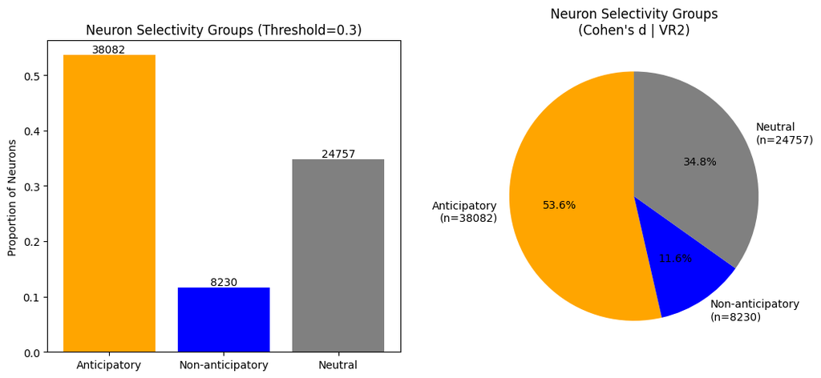

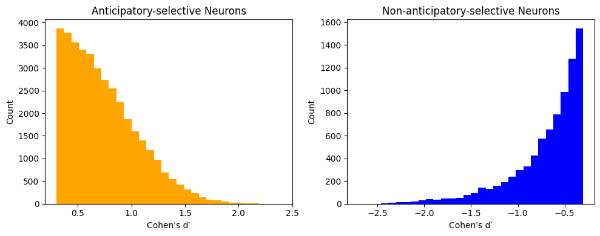

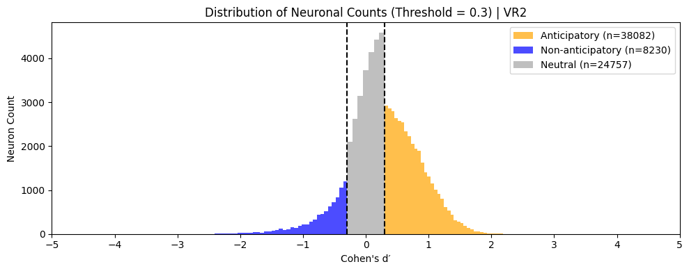

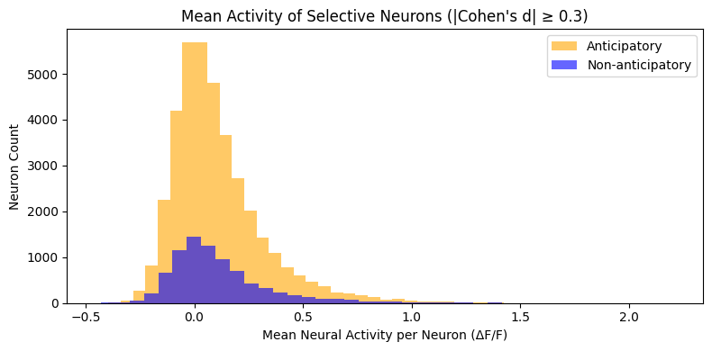

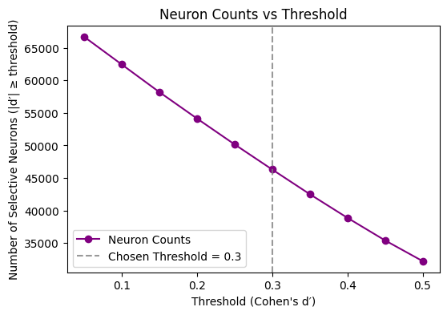

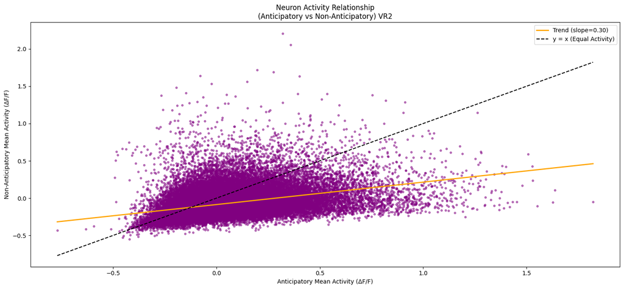

```
Slope: 0.301, R²: 0.145, p=0.000e+00
```

```python
#  @title === Neuronal Selectivity Analysis with Cohen's d ===
# VARIABLES
# ==============================
bins = 80  # <-- Change this to control ALL histograms bin sizes
threshold = 0.3 # <-- cohen's d selectivity cutoff threshold

# --- 1) Calculate Mean Activity ---
antic_means = ant_act.mean(axis=2)        # (trials, neurons)
non_antic_means = non_ant_act.mean(axis=2) # (trials, neurons)

# --- 2) Run Pipeline ---
d, antic_selective, non_selective, neutral = cohen_d_pipeline(
    antic_means, non_antic_means, threshold=threshold, bin_size=bins, animal_id=animal_id
)

# --- 3) Threshold Sensitivity ---
threshold_sensitivity(d, threshold)

# --- 4) Threshold Sensitivity ---
antic_neuron_means = ant_act.mean(axis=2).mean(axis=0)        # (n_neurons,)
non_antic_neuron_means = non_ant_act.mean(axis=2).mean(axis=0) # (n_neurons,)
# Full dataset
plot_antic_vs_nonantic_activity(antic_neuron_means, non_antic_neuron_means);
```

```python
# @title === Data Shape Cohen's d Checkpoint ===
print("\n=== Data Shape Cohen's d Checkpoint ===")
print(d, antic_selective, non_selective, neutral)
print(f"Shape of d = {d.shape}")
print(f"Shape of antic_selective = {antic_selective.shape}")
print(f"Shape of non_selective = {non_selective.shape}")
print(f"Shape of neutral = {neutral.shape}")
print(f"Shape of antic_means = {antic_means.shape}")
print(f"Shape of non_antic_means = {non_antic_means.shape}")
print(f"Values in antic_selective = {antic_selective}")
print(f"Values in non_selective = {non_selective}")
print(f"Values in neutral = {neutral}")
print(f"Values in d = {d}")
```

[output not shown]

```python
#@title *=== Regional Selectivity Functions===*
import matplotlib.pyplot as plt
import os
import seaborn as sns
def visualize_d_overlay(trans_path,
                        d_values,
                        antic_mask,
                        non_antic_mask,
                        neutral_mask,
                        animal_id="Unknown",
                        lim=None,
                        use_sub_regions=False):
    if lim is None:
        lim = get_auto_lim(trans_path)

    trans_data = np.load(trans_path, allow_pickle=True)
    mapping = sub_area_names_mapping if use_sub_regions else area_mapping

    df = pd.DataFrame({
        'x': trans_data['xpos'][lim[0]:lim[1]:lim[2]],
        'y': trans_data['ypos'][lim[0]:lim[1]:lim[2]],
        'region': pd.Series(trans_data['iarea'][lim[0]:lim[1]:lim[2]]).map(mapping),
        'd': d_values[lim[0]:lim[1]:lim[2]],
        'state': np.select(
            [antic_mask[lim[0]:lim[1]:lim[2]],
             non_antic_mask[lim[0]:lim[1]:lim[2]],
             neutral_mask[lim[0]:lim[1]:lim[2]]],
            ['Anticipatory', 'Non-Anticipatory', 'Neutral'],
            default='Other'
        )
    })

    # Plot by state
    plt.figure(figsize=(6, 5))
    sns.scatterplot(data=df, x='x', y='y', hue='state', s=5,
                    palette={'Anticipatory': 'red', 'Non-Anticipatory': 'blue', 'Neutral': 'gray'})
    plt.title(f"Cohen's d & State Overlay: {animal_id}")
    plt.show()

    return df


def quantify_region_selectivity(trans_path,
                                selectivity_mask,
                                animal_id="Unknown",
                                lim=None,
                                use_sub_regions=True,
                                label="Anticipatory",
                                plot=True):
    """
    Quantifies the proportion AND raw counts of neurons per region that meet a selectivity condition.
    Returns a DataFrame with columns: ['region', 'count', 'total', 'proportion'].
    """
    mapping = sub_area_names_mapping if use_sub_regions else area_mapping

    # Auto-detect lim if not provided
    if lim is None:
        lim = get_auto_lim(trans_path)

    trans_data = np.load(trans_path, allow_pickle=True)
    df = pd.DataFrame({
        'region': pd.Series(trans_data['iarea'][lim[0]:lim[1]:lim[2]]).map(mapping)
    })

    # Assign descriptive labels for selectivity
    df['selectivity'] = np.where(selectivity_mask[lim[0]:lim[1]:lim[2]], label, f"Not {label}")

    # Compute raw counts and proportions per region
    summary = (
        df.groupby('region')
        .apply(lambda g: pd.Series({
            'count': (g['selectivity'] == label).sum(),
            'total': len(g),
            'proportion': (g['selectivity'] == label).sum() / len(g)
        }))
        .reset_index()
    )

    # Plot proportions if requested
    if plot:
        plt.figure(figsize=(8, 5))
        sns.barplot(data=summary, x='region', y='proportion',
                    order=summary.sort_values('proportion', ascending=False)['region'])
        plt.title(f"Proportion of {label} Neurons per Region ({animal_id})")
        plt.ylabel(f"Proportion ({label} / Total)")
        plt.xticks(rotation=45)
        plt.tight_layout()
        plt.show()

    print(f"✅ Quantified {animal_id}: {len(df)} neurons analyzed ({label}).")
    return summary

# Now plot a histo with combined antic and non-antic proportions normalized for total
def plot_antic_vs_nonantic(trans_path, antic_mask, non_antic_mask,
                           animal_id="Unknown", use_sub_regions=True):
    """
    Plots the proportion of anticipatory vs non-anticipatory neurons per region.
    """
    # === Choose mapping ===
    mapping = sub_area_names_mapping if use_sub_regions else area_mapping

    # === Load transformation data ===
    trans_data = np.load(trans_path, allow_pickle=True)
    n_neurons = trans_data['xpos'].shape[0]
    regions = pd.Series(trans_data['iarea']).map(mapping)

    # === Build DataFrame with labels ===
    df = pd.DataFrame({'region': regions})
    df['antic'] = antic_mask[:n_neurons]
    df['non_antic'] = non_antic_mask[:n_neurons]

    # === Summarize proportions per region ===
    summary = (
        df.groupby('region')
        .apply(lambda g: pd.Series({
            'proportion_antic': g['antic'].sum() / len(g),
            'proportion_non_antic': g['non_antic'].sum() / len(g)
        }))
        .reset_index()
    )

    # === Melt for plotting (long format) ===
    plot_df = summary.melt(id_vars='region',
                           value_vars=['proportion_antic', 'proportion_non_antic'],
                           var_name='Type', value_name='Proportion')

    # Clean up labels
    plot_df['Type'] = plot_df['Type'].replace({
        'proportion_antic': 'Anticipatory',
        'proportion_non_antic': 'Non-Anticipatory'
    })

    # === Plot ===
    plt.figure(figsize=(9, 6))
    sns.barplot(data=plot_df, x='region', y='Proportion', hue='Type',
                order=summary.sort_values('proportion_antic', ascending=False)['region'],
                palette=['gold', 'blue'])

    plt.title(f"Proportion of Anticipatory vs Non-Anticipatory Neurons per Region ({animal_id})")
    plt.ylabel("Proportion (Normalized by Total Neurons in Region)")
    plt.xticks(rotation=45)
    plt.legend(title="Neuron Type")
    plt.tight_layout()
    plt.show()

    return summary
```

[output not shown]

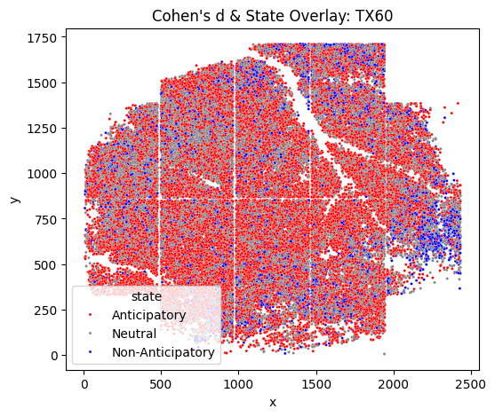

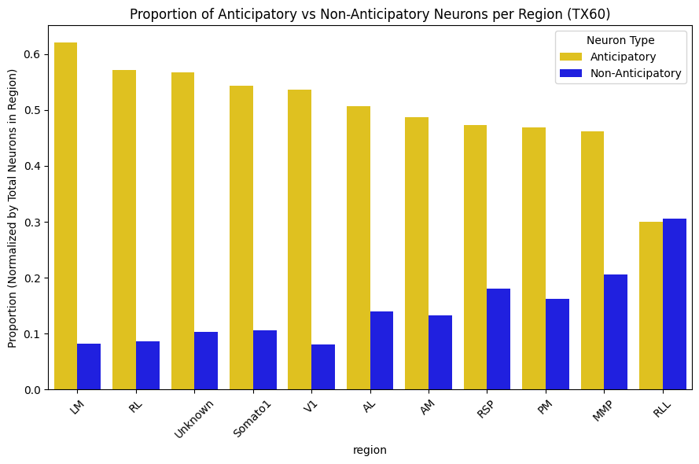

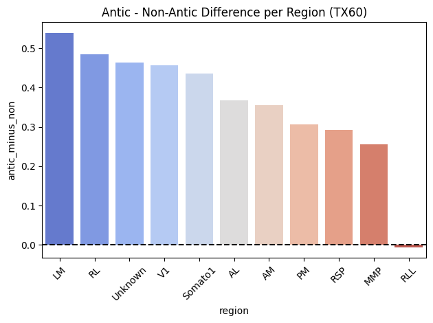

```python
# @title === Selectivity Analysis Visualization ===
TX108_trans_path = '/content/Zhong_et_al_2025/TX108_2023_01_05_trans.npz'
TX109_trans_path = '/content/Zhong_et_al_2025/TX109_2023_04_07_trans.npz'
TX60_trans_path = '/content/Zhong_et_al_2025/TX60_2021_05_04_trans.npz'
VR2_trans_path = '/content/Zhong_et_al_2025/VR2_2021_04_06_trans.npz'


# === GLOBAL MAPPINGS ===
area_codes = [-1, 0, 1, 2, 3, 4, 5, 6, 7, 8, 9]
area_names = ['Unknown', 'mHV', 'mHV', 'mHV', 'aHV', 'aHV', 'lHV', 'lHV', 'Somatosensory cortex', 'V1', 'mHV'] # Main region-level names
area_mapping = dict(zip(area_codes, area_names)) # Make into Dictionary
sub_area_names = ['Unknown', 'PM', 'AM', 'MMP', 'RL', 'RLL', 'LM', 'AL', 'Somato1', 'V1', 'RSP'] # Sub-region-level names (more detailed labels)
sub_area_names_mapping = dict(zip(area_codes, sub_area_names)) # Make into Dictionary


# === Helper Function based on the file ===
def get_auto_lim(trans_path):
    trans_data = np.load(trans_path, allow_pickle=True)
    n_neurons = trans_data['xpos'].shape[0]
    return (0, n_neurons, 1)


# === GLOBAL MASKS (Uses d values)  ===
ANTIC = antic_selective
NON_ANTIC = non_selective
NEUTRAL = neutral
use_trans_path = TX60_trans_path # === IMPORTANT: Change the Trans Path Based on Animal Being Analyzed

print("Anticipatory count:", antic_selective.sum())
print("Non-anticipatory count:", non_selective.sum())
print("Neutral count:", neutral.sum())
print("Overlap:", (antic_selective & non_selective).sum())  # should be 0

animal_select_df_with_d = visualize_d_overlay(
    use_trans_path,
    d_values=d,
    antic_mask=ANTIC,
    non_antic_mask=NON_ANTIC,
    neutral_mask=NEUTRAL,
    animal_id=animal_id,
    use_sub_regions=True
);
'''
antic_summary_animal = quantify_region_selectivity(
    use_trans_path,
    selectivity_mask=antic_selective,
    animal_id=animal_id,
    label="Anticipatory", # "Non-Anticipatory"
    plot=True
);
print(antic_summary_animal);


# @title non-antic selectivity analysis
nonantic_summary_animal = quantify_region_selectivity(
    use_trans_path,
    selectivity_mask=non_selective, # changes mask
    animal_id=animal_id,
    label="Non-Anticipatory",  # changes title
    plot=True
);
print(nonantic_summary_animal);



neutral_summary_TX109 = quantify_region_selectivity(
    use_trans_path,
    selectivity_mask=NEUTRAL, # changes mask
    animal_id=animal_id,
    label="NEUTRAL",  # changes title
    plot=True
);
print(neutral_summary_TX109);
'''
## Summaries
summary = plot_antic_vs_nonantic(
    use_trans_path,
    antic_mask=antic_selective,
    non_antic_mask=non_selective,
    animal_id=animal_id,
    use_sub_regions=True
)

summary["antic_minus_non"] = summary["proportion_antic"] - summary["proportion_non_antic"]
sns.barplot(
    data=summary,
    x="region", y="antic_minus_non",
    order=summary.sort_values("antic_minus_non", ascending=False)["region"],
    palette="coolwarm"
)
plt.title(f"Antic - Non-Antic Difference per Region ({animal_id})")
plt.axhline(0, color="black", linestyle="--")
plt.xticks(rotation=45)
plt.tight_layout()
plt.show()
```

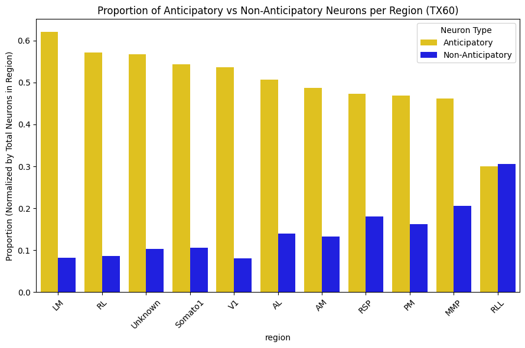

```
Saved: TX60_summary.csv
```

```python
summary = plot_antic_vs_nonantic(
    use_trans_path,
    antic_mask=antic_selective,
    non_antic_mask=non_selective,
    animal_id=animal_id,
    use_sub_regions=True
)

# Save to CSV
summary["animal"] = animal_id  # Add animal column before saving
summary.to_csv(f"{animal_id}_summary.csv", index=False)
print(f"Saved: {animal_id}_summary.csv")

#TX109_summary.csv
#TX60_summary.csv
#VR2_summary.csv
```

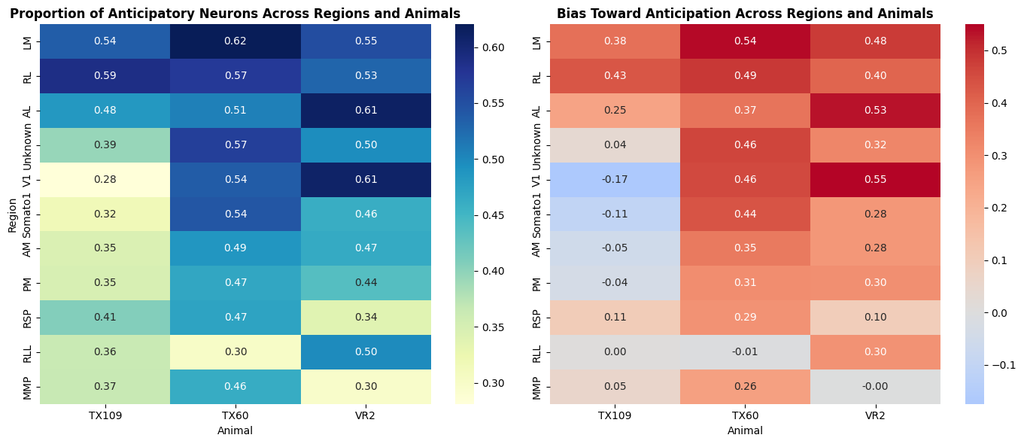

```python
import pandas as pd
import seaborn as sns
import matplotlib.pyplot as plt

# === Load all summaries ===
TX109_SUM_PATH = '/content/TX109_summary.csv'
TX60_SUM_PATH = '/content/TX60_summary.csv'
VR2_SUM_PATH  = '/content/VR2_summary.csv'

TX109_summary = pd.read_csv(TX109_SUM_PATH)
TX60_summary = pd.read_csv(TX60_SUM_PATH)
VR2_summary = pd.read_csv(VR2_SUM_PATH)

import pandas as pd
import seaborn as sns
import matplotlib.pyplot as plt

# === Combine Summaries ===
all_summaries = pd.concat([TX109_summary, TX60_summary, VR2_summary], ignore_index=True)

# === Region Ordering (sorted by avg proportion_antic) ===
region_order = (
    all_summaries.groupby('region')['proportion_antic']
    .mean()
    .sort_values(ascending=False)
    .index.tolist()
)

# === Pivot for Heatmaps ===
heatmap_df = all_summaries.pivot(index="region", columns="animal", values="proportion_antic")
heatmap_df = heatmap_df.loc[region_order]

all_summaries["antic_minus_non"] = (
    all_summaries["proportion_antic"] - all_summaries["proportion_non_antic"]
)
diff_heatmap_df = all_summaries.pivot(index="region", columns="animal", values="antic_minus_non")
diff_heatmap_df = diff_heatmap_df.loc[region_order]

# === Plot Side-by-Side Heatmaps ===
plt.figure(figsize=(14, 6))

# --- Left Heatmap: Proportion ---
plt.subplot(1, 2, 1)
sns.heatmap(
    heatmap_df, annot=True, fmt=".2f",
    cmap="YlGnBu", cbar=True
)
plt.title("Proportion of Anticipatory Neurons Across Regions and Animals", fontsize=12, weight='bold')
plt.xlabel("Animal")
plt.ylabel("Region")

# --- Right Heatmap: Bias (Antic − Non-Antic) ---
plt.subplot(1, 2, 2)
sns.heatmap(
    diff_heatmap_df, annot=True, fmt=".2f",
    cmap="coolwarm", center=0, cbar=True
)
plt.title("Bias Toward Anticipation Across Regions and Animals", fontsize=12, weight='bold')
plt.xlabel("Animal")
plt.ylabel("")

plt.tight_layout()
plt.show()
```

Now We PCA

```python
# @title *=== Data Flatten, PCA Visualize, t-SNE Function ===*
import numpy as np
import matplotlib.pyplot as plt
from sklearn.decomposition import PCA
from sklearn.preprocessing import StandardScaler

def pca_flattened_vs_avg(ant_act, non_ant_act, n_components=2, animal_id="Unknown", scale=False):
  '''
  Runs PCA on flattened & averaged data
  '''
  # Combine Data
  X_all = np.concatenate([ant_act, non_ant_act], axis = 0)
  print(f"Shape of X_all = {X_all.shape}")
  labels = np.concatenate([np.ones(len(ant_act)), np.zeros(len(non_ant_act))])
  print(f"Shape of labels = {labels.shape}")

  print("PCA running...")
  # === Flattened Representation ===
  X_flat = X_all.reshape(X_all.shape[0], -1)
  if scale:
      X_flat = StandardScaler().fit_transform(X_flat)
  pca_model_flat = PCA(n_components=n_components)
  pca_flat = pca_model_flat.fit_transform(X_flat)

  # === Averaged Representation ===
  X_avg = X_all.mean(axis=2)
  if scale:
      X_avg = StandardScaler().fit_transform(X_avg)
  pca_model_avg = PCA(n_components=n_components)
  pca_avg = pca_model_avg.fit_transform(X_avg)


  # === Visualization ===
  fig, axs = plt.subplots(1, 2, figsize=(14, 5))

  scatter1 = axs[0].scatter(
      pca_flat[:, 0], pca_flat[:, 1],
      c=labels, cmap='coolwarm', edgecolor='black', s=40, alpha=0.85
  )
  axs[0].set_title(f"{animal_id} PCA: Flattened Neuron × Time", fontsize=12, weight='bold')
  axs[0].set_xlabel("PC1", fontsize=11)
  axs[0].set_ylabel("PC2", fontsize=11)
  axs[0].grid(alpha=0.3)

  scatter2 = axs[1].scatter(
      pca_avg[:, 0], pca_avg[:, 1],
      c=labels, cmap='coolwarm', edgecolor='black', s=40, alpha=0.85
  )
  axs[1].set_title(f"{animal_id} PCA: Averaged Across Time", fontsize=12, weight='bold')
  axs[1].set_xlabel("PC1", fontsize=11)
  axs[1].set_ylabel("PC2", fontsize=11)
  axs[1].grid(alpha=0.3)

  # --- Shared Colorbar (Forced Further to Right) ---
  cbar = fig.colorbar(
      scatter2,
      ax=axs,
      orientation='vertical',
      fraction=0.046,  # thickness of the bar
      pad=0.04         # <-- increase this to push further right (default ~0.04)
  )
  cbar.set_ticks([0, 1])
  cbar.set_ticklabels(['Non-anticipatory', 'Anticipatory'])

  plt.tight_layout(rect=[0, 0, 0.86, 1])  #  give more space for the bar
  plt.show()

  return {
      "X_flat": X_flat, # (n_trials, n_neurons * n_timepoints) = flattened trial data (neurons x time collapsed to 1d)
      "pca_flat": pca_flat, #  (n_trials, n_components) = PCA-transformed scores for flatt input
      "pca_model_flat": pca_model_flat,   # PCA object containing explained variance
      "X_avg": X_avg,  # (n_trials, n_neurons) = time avg activity per trials (means across frames)
      "pca_avg": pca_avg, # (n_trials, n_components) = PCA-transformed scores for avg input
      "pca_model_avg": pca_model_avg,     # PCA object = containing the explained_variance_ratio_ and components_ for avg PCA
      "labels": labels #(n_trials) = 1 = antic trials | 0 = non-antic trials
  }

from sklearn.manifold import TSNE
import matplotlib.pyplot as plt
import numpy as np

def tsne_from_existing_pca(pca_results, use="avg", tsne_perplexity=30, random_state=42, animal_id="Unknown", plot=True):
    """
    Runs t-SNE on the PCA results from `pca_flattened_vs_avg`.

    Args:
        pca_results (dict): Output from `pca_flattened_vs_avg`.
        use (str): Which data to use: "avg" (averaged across time) or "flat" (flattened neuron × time).
        tsne_perplexity (int): t-SNE perplexity.
        random_state (int): Random seed for reproducibility.
        animal_id (str): For plot title.
        plot (bool): Whether to show the t-SNE embedding.

    Returns:
        dict: {
            "X_pca": (n_trials, n_components),
            "X_tsne": (n_trials, 2),
            "labels": (n_trials,)
        }
    """

    # === Select PCA output ===
    if use == "avg":
        X_pca = pca_results["pca_avg"] # uses  (n_trials, n_components) = PCA-transformed scores for avg input
    elif use == "flat":
        X_pca = pca_results["pca_flat"] # uses (n_trials, n_components) = PCA-transformed scores for flatt input
    else:
        raise ValueError("use either 'avg' or 'flat' !")

    labels = pca_results["labels"]

    # === Run t-SNE ===
    tsne = TSNE(
        n_components=2,
        perplexity=tsne_perplexity,
        learning_rate='auto',
        init='pca',
        random_state=random_state
    )
    X_tsne = tsne.fit_transform(X_pca)

    # === Visualization ===
    if plot:
        plt.figure(figsize=(7, 6))
        sc = plt.scatter(X_tsne[:, 0], X_tsne[:, 1], c=labels, cmap='coolwarm',
                         edgecolor='k', alpha=0.8)
        plt.title(f"{animal_id} t-SNE Embedding ({'Averaged' if use=='avg' else 'Flattened'})", fontsize=12, weight='bold')
        plt.xlabel('t-SNE 1')
        plt.ylabel('t-SNE 2')
        cbar = plt.colorbar(sc)
        cbar.set_ticks([0, 1])
        cbar.set_ticklabels(['Non-anticipatory', 'Anticipatory'])
        plt.grid(True, alpha=0.3)
        plt.tight_layout()
        plt.show()

    return {
        "X_pca": X_pca,
        "X_tsne": X_tsne,
        "labels": labels
    }
```

```
Shape of X_all = (452, 71069, 3)
Shape of labels = (452,)
PCA running...
```

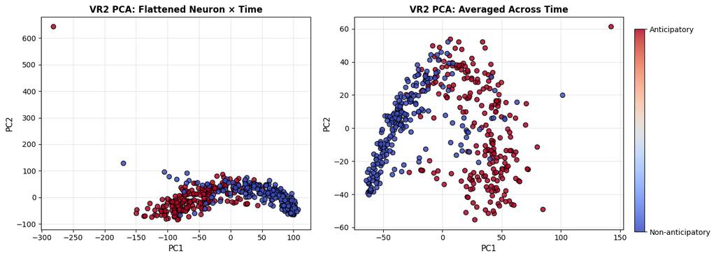

```
✅PCA Complete
Keys inside of animal_pca_results:
dict_keys(['X_flat', 'pca_flat', 'pca_model_flat', 'X_avg', 'pca_avg', 'pca_model_avg', 'labels'])
```

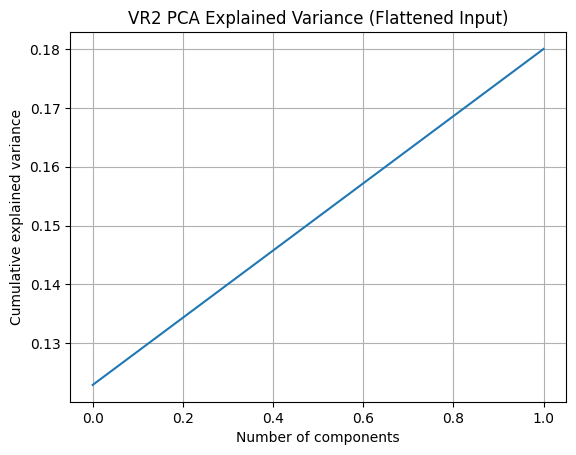

```
Running t-SNE...
```

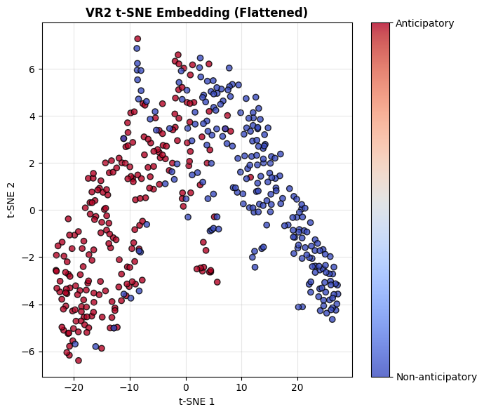

```
✅t-SNE Complete
Keys inside of tsne_results_avg:
dict_keys(['X_pca', 'X_tsne', 'labels'])
```

```python
# @title == PCA and t-SNE ===

# === Run PCA and get Results ===
animal_pca_results = pca_flattened_vs_avg(ant_act, non_ant_act, animal_id= animal_id)
print(f"✅PCA Complete \nKeys inside of animal_pca_results:\n{animal_pca_results.keys()}")

plt.plot(np.cumsum(animal_pca_results['pca_model_flat'].explained_variance_ratio_))
plt.xlabel("Number of components")
plt.ylabel("Cumulative explained variance")
plt.title(f"{animal_id} PCA Explained Variance (Flattened Input)")
plt.grid(True)
plt.show()


# === Run t-SNE directly on the PCA results ===
print("\nRunning t-SNE...")
tsne_results_avg = tsne_from_existing_pca(
    animal_pca_results,
    use="flat",            # "avg" or "flat"
    tsne_perplexity=50,
    animal_id=animal_id
)
print("✅t-SNE Complete")
print(f"Keys inside of tsne_results_avg:\n{tsne_results_avg.keys()}")
```

```python
##############################################################
```

**Now Pipeline for the Unsupervised Mice**

```python
# @title Load Unsupervised Mice Data
# @title Download SVD dec Neural Data (You dont Need All But This Get All) (1minute)
# GET NEURONAL DATA

import os
import requests

# === Setup ===
root = '/content/Zhong_et_al_2025/'
neural_dir = os.path.join(root, 'ca_data')
os.makedirs(neural_dir, exist_ok=True)

# === Target animals ===
target_animals = ['TX104', 'TX123', 'TX119']  # Names of Animals

# === Figshare Setup ===
BASE_URL = 'https://api.figshare.com/v2'
article_id = 28811129

# === Get file metadata from Figshare ===
response = requests.get(f'{BASE_URL}/articles/{article_id}')
metadata = response.json()
figshare_files = {f['name']: f['id'] for f in metadata['files']}

# === Filter SVD_dec files by animal name (case-insensitive) ===
svd_filenames = [
    fname for fname in figshare_files
    if fname.lower().endswith('_svd_dec.npy') and
       any(animal.lower() in fname.lower() for animal in target_animals)
]

# === Download matched files ===
for fname in svd_filenames:
    save_path = os.path.join(neural_dir, fname)
    if os.path.exists(save_path):
        print(f"✅ Already downloaded: {fname}")
    else:
        print(f"⬇️ Downloading: {fname}")
        file_id = figshare_files[fname]
        file_url = f"{BASE_URL}/file/download/{file_id}"
        file_resp = requests.get(file_url)
        with open(save_path, 'wb') as f:
            f.write(file_resp.content)

# @title load position data

import os
import requests

# === Setup ===
root = '/content/Zhong_et_al_2025/'
neural_dir = os.path.join(root, 'trans')
os.makedirs(neural_dir, exist_ok=True)

# === Target animals ===
target_animals = ['TX104', 'TX123', 'TX119']  # Names of Animals

# === Figshare Setup ===
BASE_URL = 'https://api.figshare.com/v2'
article_id = 28811129

# === Get file metadata from Figshare ===
response = requests.get(f'{BASE_URL}/articles/{article_id}')
metadata = response.json()
figshare_files = {f['name']: f['id'] for f in metadata['files']}

# === Filter trans files by animal name (case-insensitive) ===
trans_filenames = [
    fname for fname in figshare_files
    if fname.lower().endswith('trans.npz') and
       any(animal.lower() in fname.lower() for animal in target_animals)
]

# === Download matched files ===
for fname in trans_filenames:
    save_path = os.path.join(neural_dir, fname)
    if os.path.exists(save_path):
        print(f"✅ Already downloaded: {fname}")
    else:
        print(f"⬇️ Downloading: {fname}")
        file_id = figshare_files[fname]
        file_url = f"{BASE_URL}/file/download/{file_id}"
        file_resp = requests.get(file_url)
        with open(save_path, 'wb') as f:
            f.write(file_resp.content)
```

```
⬇️ Downloading: TX119_2023_12_24_1_SVD_dec.npy
⬇️ Downloading: TX123_2024_01_16_1_SVD_dec.npy
⬇️ Downloading: TX123_2023_12_21_1_SVD_dec.npy
⬇️ Downloading: TX119_2023_12_14_1_SVD_dec.npy
⬇️ Downloading: TX119_2023_12_12_1_SVD_dec.npy
⬇️ Downloading: TX123_2024_01_15_1_SVD_dec.npy
⬇️ Downloading: TX119_2024_01_06_1_SVD_dec.npy
⬇️ Downloading: TX123_2024_01_03_1_SVD_dec.npy
⬇️ Downloading: TX119_2023_12_23_1_SVD_dec.npy
⬇️ Downloading: TX123_2024_01_17_1_SVD_dec.npy
⬇️ Downloading: TX104_2022_10_20_1_SVD_dec.npy
⬇️ Downloading: TX119_2023_12_13_1_SVD_dec.npy
⬇️ Downloading: TX119_2024_01_07_1_SVD_dec.npy
⬇️ Downloading: TX104_2022_10_12_1_SVD_dec.npy
⬇️ Downloading: TX119_2024_01_09_1_SVD_dec.npy
⬇️ Downloading: TX123_2023_12_20_1_SVD_dec.npy
⬇️ Downloading: TX123_2024_01_02_1_SVD_dec.npy
⬇️ Downloading: TX123_2023_12_18_1_SVD_dec.npy
⬇️ Downloading: TX104_2022_10_12_trans.npz
⬇️ Downloading: TX104_2022_10_20_trans.npz
⬇️ Downloading: TX119_2023_12_12_trans.npz
⬇️ Downloading: TX119_2023_12_13_trans.npz
⬇️ Downloading: TX119_2023_12_14_trans.npz
⬇️ Downloading: TX119_2023_12_23_trans.npz
⬇️ Downloading: TX119_2023_12_24_trans.npz
⬇️ Downloading: TX119_2024_01_06_trans.npz
⬇️ Downloading: TX119_2024_01_07_trans.npz
⬇️ Downloading: TX123_2023_12_18_trans.npz
⬇️ Downloading: TX123_2023_12_20_trans.npz
⬇️ Downloading: TX119_2024_01_09_trans.npz
⬇️ Downloading: TX123_2023_12_21_trans.npz
⬇️ Downloading: TX123_2024_01_02_trans.npz
⬇️ Downloading: TX123_2024_01_03_trans.npz
⬇️ Downloading: TX123_2024_01_15_trans.npz
⬇️ Downloading: TX123_2024_01_16_trans.npz
⬇️ Downloading: TX123_2024_01_17_trans.npz
```

```python
# @title *=== Functions: Pre-Process + Neural Data Loading ===*
import requests
import json
import ast
import numpy as np
import pandas as pd
import os
import matplotlib.pyplot as plt
import seaborn as sns

# Load Neuronal Dataset
def load_neurons_for_subject(file_path):
    """
    Returns:
        np.ndarray: Reconstructed neural activity (timepoints × neurons)
    """
    if file_path.endswith('.npy'):
        data = np.load(file_path, allow_pickle=True).item()
        if 'U' in data and 'V' in data:
            U = data['U'].T  # Transpose: (timepoints × components)
            V = data['V']    # (components × neurons)
            neural_data = U @ V  # Reconstruct: (timepoints × neurons)
        else:
            raise ValueError(f"Error in {file_path}")

    elif file_path.endswith('.npz'):
        data = np.load(file_path, allow_pickle=True)
        var_name = [key for key in data.keys() if 'rec' in key][0]
        neural_data = data[var_name]

    else:
        raise ValueError("File must be a .npy or .npz")

    print(f"✅ Loaded and reconstructed neural data from: {file_path}")
    print(f"Shape (timepoints × neurons): {neural_data.shape}")
    return neural_data

####
import pandas as pd
def load_and_preprocess(csv_path, stimulus_filter = None):
  print(f"\nLoading {csv_path} ...")
  df = pd.read_csv(csv_path)

  if stimulus_filter:
    df = df[df['stimulus']== stimulus_filter]

  df = df.reset_index(drop=True) # Reset Index

  df['lickFrames'] = df['lickFrames'].apply(
      lambda x: ast.literal_eval(x) if isinstance(x, str) else x
  )
  print(f"✅ Finished preprocessing | Shape: {df.shape}")


  return df
#####
def clean_trials(lick_df):
    """
    Args: lick_df (pd.DataFrame): Lick trial dataframe.

    Returns: pd.DataFrame: Cleaned trials dataframe. list: Skipped trial numbers. list: Issue trial numbers.
    """
    skipped_trials, issue_trials, cleaned_trials = [], [], []
    print(f"\n🟧 Cleaning Dataset| Shape of Dataframe (pre): {lick_df.shape}")

    for idx in range(len(lick_df)):
        trial = lick_df.iloc[idx]
        trial_lick_frames = trial['lickFrames']

        # Case 1: No licks recorded
        if len(trial_lick_frames) == 0:
            print(f"[Skipped] Trial index {idx} (TrialNumber {trial['trialNumber']}): No licks recorded.")
            skipped_trials.append(trial['trialNumber'])
            continue

        # Case 2: Last lick < reward frame
        if trial_lick_frames[-1] < trial['rewardFrame']:
            print(
                f"[Issue] Trial index {idx} (TrialNumber {trial['trialNumber']}): "
                f"Last lick ({trial_lick_frames[-1]}) < Reward frame ({trial['rewardFrame']})"
            )
            issue_trials.append(trial['trialNumber'])
            continue

        # Otherwise: keep trial
        cleaned_trials.append(trial)

    cleaned_subject_trials = pd.DataFrame(cleaned_trials)

    # ✅ Summary
    total_tossed = len(skipped_trials) + len(issue_trials)
    print("✅ Cleaning Complete")
    print(f"Shape of Cleaned Dataframe (post): {cleaned_subject_trials.shape}")
    print(f"Total trials tossed: {total_tossed}")
    #print(f"Skipped Trials (no licks): {skipped_trials}")
    #print(f"Issue Trials (last lick < reward frame): {issue_trials}")
    print(f"Remaining trials: {cleaned_subject_trials.shape[0]}\n")

    return cleaned_subject_trials, skipped_trials, issue_trials

def extract_antic_nonantic_activity(neural_data,cleaned_trials,window = 3):
  '''Extracts anticipatory & non-anticipatory activity from neural data.
    Args:
        neural_data (np.ndarray): Shape (n_neurons, n_frames)
        cleaned_trials (pd.DataFrame): Pre-cleaned trials with lickFrames
        window (int): Number of frames to include before each lick

    Returns:
      tuple: (antic_activity, non_antic_activity), each (trials × neurons × frames)  '''

  trial_ant_act, trial_non_act = [], []
  max_frame = neural_data.shape[1] - 1  # The max frame index

  print("\n💻 Extracting Anticipatory & Non-Anticipatory Activity")
  print(f"Neural Data Shape (input): {neural_data.shape}")
  print(f"Total Cleaned Trials: {cleaned_trials.shape[0]}\n")

  for i in range(len(cleaned_trials)):
    trial = cleaned_trials.iloc[i] # loop through trials
    trial_lick_frames = trial['lickFrames']

    trial_antic_lick = int(trial_lick_frames[0]) # first lick
    trial_n_antic_lick = int(trial_lick_frames[-1]) # last lick

    # Safe frame windows (avoid exceeding max_frame)
    antic_frames = [f for f in range(trial_antic_lick - window, trial_antic_lick) # frames in window before antic lick
                    if 0 <= f <= max_frame] # range of the specified frames for first lick !> than max or less than 0
    non_antic_frames = [f for f in range(trial_n_antic_lick - window, trial_n_antic_lick) # frames in window before non-antic lick
                        if 0 <= f <= max_frame] # range of the specified frames for last lick !> than max or less than 0

    # Skip incomplete windows
    if len(antic_frames) != window or len(non_antic_frames) != window:
      print(f"⏩ Skipping Trial {trial['trialNumber']} (Index {i}): "
          f"antic_frames={len(antic_frames)}/{window}, "
          f"non_antic_frames={len(non_antic_frames)}/{window}, "
          f"lickFrames={trial_lick_frames}, "
          f"rewardFrame={trial['rewardFrame']}")
      continue

    # Slice neural activity (neurons × frames)
    trial_ant_act.append(neural_data[:, antic_frames])
    trial_non_act.append(neural_data[:, non_antic_frames])

  trial_ant_act = np.stack(trial_ant_act)  # anticipatory activity list
  trial_non_act = np.stack(trial_non_act) # non-anticipatory activity list

  print(f"\n✅ Finished Processing {trial_ant_act.shape[0]} Trials")
  print(f"Anticipatory Activity Shape: {trial_ant_act.shape}")
  print(f"Non-Anticipatory Activity Shape: {trial_non_act.shape}")

  return trial_ant_act, trial_non_act

def match_neural_to_trials(neural_data, cleaned_trials):
    # Filters neural data to keep only frames from cleaned trials.

    valid_trial_ids = cleaned_trials['trialNumber'].values.astype(int)
    neural_data_cleaned = neural_data[valid_trial_ids, :]
    print(f"\n✅ Neural Data Matched to Cleaned Trials: {neural_data_cleaned.shape}")
    return neural_data_cleaned


# Function For getting additional data
def download_npy_from_figshare(root, target_file, article_id=28811129):
    """
    Download a .npy file from Figshare to the specified root directory.

    Args:
        root (str): Directory where the file should be saved.
        target_file (str): Name of the .npy file to download (must match Figshare listing).
        article_id (int): Figshare article ID (default is Zhong et al., 2025: 28811129).

    Returns:
        str: Local file path to the downloaded file.
    """
    os.makedirs(root, exist_ok=True)
    FIGSHARE_API = "https://api.figshare.com/v2"

    # Get file list from Figshare
    response = requests.get(f"{FIGSHARE_API}/articles/{article_id}")
    file_list = response.json()['files']

    # Search for the target file
    file_url = None
    for f in file_list:
        if f['name'] == target_file:
            file_url = f['download_url']
            break

    if file_url is None:
        raise FileNotFoundError(f"❌ {target_file} not found in Figshare article {article_id}.")

    # Download the file
    save_path = os.path.join(root, target_file)
    if not os.path.exists(save_path):  # Avoid re-downloading if already present
        print(f"⬇️ Downloading {target_file} ...")
        r = requests.get(file_url)
        with open(save_path, 'wb') as f:
            f.write(r.content)
        print(f"✅ Downloaded and saved to {save_path}")
    else:
        print(f"✔️ File already exists locally: {save_path}")

    return save_path
```

```python
# @title === [UNSUPERVISED] Download Beh_unsup_train1_after_learning.npy  ===
root = "/content/Zhong_et_al_2025/neural_data"
target_file = "Beh_unsup_train1_after_learning.npy" # Change THIS variable to name of file that you want to download
downloaded_path = download_npy_from_figshare(root, target_file)

beh_after_training = np.load(os.path.join(downloaded_path), allow_pickle=1).item()
ls_unsup_mice = list(beh_after_training.keys())
print(f"Keys in {downloaded_path}:\n{ls_unsup_mice}")
```

```
✔️ File already exists locally: /content/Zhong_et_al_2025/neural_data/Beh_unsup_train1_after_learning.npy
Keys in /content/Zhong_et_al_2025/neural_data/Beh_unsup_train1_after_learning.npy:
['TX83_2022_08_29_1', 'TX88_2022_06_17_2', 'TX105_2022_10_19_2', 'TX104_2022_10_20_1', 'TX119_2023_12_23_1', 'TX123_2024_01_02_1', 'DR10_2022_07_19_1', 'DR15_2022_10_19_1', 'TX85_2022_06_17_1']
```

```python
# @title === [UNSUPERVISED] Load the Lick Data CSV ===
from google.colab import files
print('Please Upload [UNSUPERVISED] Lick Data CSV: ')
uploaded = files.upload()
```

[output not shown]

```python
# @title === Clean Data ===
csv_filename = 'TX104_2022_10_20_1_lickData.csv'
# Read the CSV file into a pandas DataFrame
try:
    df = pd.read_csv(io.BytesIO(uploaded[csv_filename]))
    print(f"Successfully loaded {csv_filename}")
    display(df.head())
except KeyError:
    print(f"Error: File '{csv_filename}' not found in uploaded files.")
except Exception as e:
    print(f"An error occurred while reading the CSV: {e}")


### ### ###

df['rewardFrame'] = 1 # Change all values in the 'rewardFrame' column to 1


# Modify the 'lickFrames' column
df['lickFrames'] = df.apply(lambda row: [int(row['trStartFrame']) + 9, int(row['trEndFrame'])], axis=1) # For each row, set 'lickFrames' to a list containing trStartFrame + 1 and trEndFrame

# Save the modified DataFrame to original CSV file (overwrite) | Set index = False
try:
    df.to_csv(csv_filename, index=False)
    print(f"Successfully updated '{csv_filename}' with all 'rewardFrame' values set to 1 and 'lickFrames' modified.")
except Exception as e:
    print(f"An error occurred while saving the CSV file: {e}")
# Optional: Load the CSV again to verify the changes
df_verified = pd.read_csv(csv_filename)
print("\nVerifying the first few rows after saving:")
display(df_verified.head())
```

```python
# @title === [UNSUPERVISED] Neural Data Loading ===
# ================== Neural Data Paths ==================
TX104_neural_data_path = '/content/Zhong_et_al_2025/ca_data/TX104_2022_10_20_1_SVD_dec.npy'

# ================== Neural Data Loading (Load ONE per Runtime) ==================
TX104_neural_data = load_neurons_for_subject(TX104_neural_data_path)

# ================== Trans Data Paths  ==================
TX104_trans_path = '/content/Zhong_et_al_2025/trans/TX104_2022_10_20_trans.npz'

# ================== Trans Data Loading  ==================
trans_data = np.load(TX104_trans_path, allow_pickle=True)
```

```
✅ Loaded and reconstructed neural data from: /content/Zhong_et_al_2025/ca_data/TX104_2022_10_20_1_SVD_dec.npy
Shape (timepoints × neurons): (42565, 16171)
```

```python
# Lick Data Paths
TX104_lick_data_path = 'unknown'

# @title === Data Extraction Pipeline ===
# =================== SET ANIMAL ID  ===========================   ===========================
animal_id = "TX104"
Subject_neural_data = TX104_neural_data # change per dataset
Subject_lick_data_path = TX104_lick_data_path # change per dataset
#  ===========================   ===========================   ===========================

# === [UNSUPERVISED] PIPELINE STARTS HERE ===

# 1) Load Lick Data and Clean Trials
subject_lick_data = load_and_preprocess(Subject_lick_data_path, stimulus_filter='leaf1') # Subject lick data + stimulus of interest
subject_cleaned_trials, _, _ = clean_trials(subject_lick_data) # Clean df for empty or non-usuable trials
# Output = df(trials, frames)

# 2) Load and reconstruct neural data (SVD)
# Output = (timepoints, neurons)

# 3) Extract anticipatory & non-anticipatory activity
animal_trial_ant_act, animal_trial_non_act = extract_antic_nonantic_activity( # get activity during each trial's frames
    Subject_neural_data, subject_cleaned_trials, window=3 # neural data, trial data, window size
)
# Output = (trials, neurons, activity_frames)


# @title === Data Shape Checkpoint ===
ant_act = animal_trial_ant_act
non_ant_act = animal_trial_non_act
# Example Data Parsing
print(f'Shape of TX60_trial_ant_act: {ant_act.shape}')
print(f'Shape of TX60_trial_ant_act[1]: {ant_act[1].shape}')
print(f'Shape of TX60_trial_ant_act[1][1]: {ant_act[1][1].shape}')
print(f'Activity of Neurons at Trial 1 Neuron 1: {ant_act[1][1][:]}')
print(f'Activity of Neurons at Trial 1 Neuron 2: {ant_act[1][2][:]}]')
print(f'Activity of Neurons at Trial 1 Neuron 3: {ant_act[1][3][:]}')
```

[output not shown]

```python
#@title *=== Complete Pipeline Function Package ===*
# @title *Calculate Signifigance Analysis Functions (cohen's d)*
import numpy as np
import matplotlib.pyplot as plt
from scipy.stats import linregress

# Functions for Calculating Cohens D
def calculate_d(avg_neurons_a, avg_neurons_n, eps=1e-8):
    """Calculate Cohen's d' for each neuron with numerical stability."""
    u1 = np.nanmean(avg_neurons_a, axis=0)
    u2 = np.nanmean(avg_neurons_n, axis=0)
    sig1 = np.nanstd(avg_neurons_a, axis=0)
    sig2 = np.nanstd(avg_neurons_n, axis=0)
    d = 2 * (u1 - u2) / (sig1 + sig2)
    return d # Returns an array of d values

def cohen_d_pipeline(antic_means, non_antic_means, threshold=0.2, bin_size=40, animal_id="TX108"):
    """
    Full pipeline: calculates Cohen's d, thresholds neurons, and visualizes results.
    """
    # --- 1) Compute Cohen's d ---
    d = calculate_d(antic_means, non_antic_means) # uses function above
    antic_selective = d >= threshold # get selective anticipatory booleans
    non_selective = d <= -threshold # get selective non-anticipatory booleans
    neutral = (d > -threshold) & (d < threshold) # get nonselective (neutral) booleans

    antic_count = antic_selective.sum() # number of
    non_count = non_selective.sum() # number of
    neutral_count = neutral.sum() # number of

    print(f"\n✅ Cohen's d Calculated for {len(d)} neurons")
    print(f"Anticipatory-selective: {antic_count}")
    print(f"Non-anticipatory-selective: {non_count}")
    print(f"Neutral: {neutral_count}")

    # ================================
    # --- Combined Bar + Pie Chart ---
    fig, axes = plt.subplots(1, 2, figsize=(11, 5))

    # --- BAR CHART (Proportions) ---
    total = antic_count + non_count + neutral_count
    proportions = [antic_count / total, non_count / total, neutral_count / total]
    labels = ['Anticipatory', 'Non-anticipatory', 'Neutral']
    colors = ['orange', 'blue', 'gray']

    bars = axes[0].bar(labels, proportions, color=colors)
    for bar, count in zip(bars, [antic_count, non_count, neutral_count]):
        axes[0].text(bar.get_x() + bar.get_width()/2, bar.get_height(),
                     f"{count}", ha='center', va='bottom')
    axes[0].set_ylabel("Proportion of Neurons")
    axes[0].set_title(f"Neuron Selectivity Groups (Threshold={threshold})")

    # --- PIE CHART WITH COUNTS (IN THE SAME FIGURE) ---
    counts = [antic_count, non_count, neutral_count]
    pie_labels = [
        f"Anticipatory\n(n={antic_count})",
        f"Non-anticipatory\n(n={non_count})",
        f"Neutral\n(n={neutral_count})"
    ]
    axes[1].pie(
        counts,
        labels=pie_labels,
        colors=colors,
        autopct='%1.1f%%',
        startangle=90
    )
    axes[1].set_title(f"Neuron Selectivity Groups\n(Cohen's d | {animal_id})")

    plt.tight_layout()
    plt.show()

    # ======================
    # --- SPLIT HISTOS ---
    fig, axs = plt.subplots(1, 2, figsize=(10, 4))
    axs[0].hist(d[antic_selective], bins=30, color='orange')
    axs[0].set_title("Anticipatory-selective Neurons")
    axs[0].set_xlabel("Cohen's d′")
    axs[0].set_ylabel("Count")

    axs[1].hist(d[non_selective], bins=30, color='blue')
    axs[1].set_title("Non-anticipatory-selective Neurons")
    axs[1].set_xlabel("Cohen's d′")
    axs[1].set_ylabel("Count")

    plt.tight_layout()
    plt.show()

    # ================================
    # --- 4) CLASSIC HISTOGRAM OVERLAY (Counts + Threshold Lines) ---
    plt.figure(figsize=(10, 4))
    plt.hist(d[antic_selective], bins=40, color='orange', alpha=0.7,
             label=f'Anticipatory (n={antic_count})')
    plt.hist(d[non_selective], bins=40, color='blue', alpha=0.7,
             label=f'Non-anticipatory (n={non_count})')
    plt.hist(d[neutral], bins=7, color='gray', alpha=0.5,
             label=f'Neutral (n={neutral_count})')

    plt.axvline(threshold, color='black', linestyle='--')
    plt.axvline(-threshold, color='black', linestyle='--')
    plt.xlabel("Cohen's d′")
    plt.xlim(-5, 5)
    plt.xticks(np.arange(-5, 6, 1))
    plt.ylabel("Neuron Count")
    plt.title(f"Distribution of Neuronal Counts (Threshold = {threshold}) | {animal_id}")
    plt.legend()
    plt.tight_layout()
    plt.show()

        # ================================
    # --- 5) MEAN NEURAL ACTIVITY DISTRIBUTIONS ---
    antic_neuron_means = antic_means.mean(axis=0)        # (n_neurons,)
    non_antic_neuron_means = non_antic_means.mean(axis=0) # (n_neurons,)

    # --- 2) Select only neurons above threshold ---
    selected_antic_means = antic_neuron_means[antic_selective]
    selected_non_antic_means = non_antic_neuron_means[non_selective]

    plt.figure(figsize=(8, 4))
    plt.hist(selected_antic_means, bins=40, color='orange', alpha=0.6, label='Anticipatory')
    plt.hist(selected_non_antic_means, bins=40, color='blue', alpha=0.6, label='Non-anticipatory')
    plt.xlabel("Mean Neural Activity per Neuron (ΔF/F)")
    plt.ylabel("Neuron Count")
    plt.title(f"Mean Activity of Selective Neurons (|Cohen's d| ≥ {threshold})")
    plt.legend()
    plt.tight_layout()
    plt.show()

    return d, antic_selective, non_selective, neutral


def threshold_sensitivity(d, chosen_threshold=0.2):
    thresholds = np.linspace(0.05, 0.5, 10)
    counts = [np.sum((d >= t) | (d <= -t)) for t in thresholds]
    plt.figure(figsize=(6, 4))
    plt.plot(thresholds, counts, 'o-', color='purple', label="Neuron Counts")
    plt.axvline(chosen_threshold, color='gray', linestyle='--', alpha=0.8, label=f"Chosen Threshold = {chosen_threshold}")
    plt.xlabel("Threshold (Cohen's d′)")
    plt.ylabel("Number of Selective Neurons (|d′| ≥ threshold)")
    plt.title("Neuron Counts vs Threshold")
    plt.legend()
    plt.show()


def plot_antic_vs_nonantic_activity(antic_means, non_antic_means, sample_range=None):
    """
    Plots anticipatory vs non-anticipatory mean neural activity with regression analysis.

    Args:
        antic_means (np.ndarray): Mean anticipatory activity per neuron (n_neurons,).
        non_antic_means (np.ndarray): Mean non-anticipatory activity per neuron (n_neurons,).
        sample_range (tuple or None): If provided (start, stop), restricts to this slice.
```

```python
    Returns:
        slope (float), intercept (float), r_squared (float), p_value (float)
    """
    # ✅ Optional sampling (e.g., first 100 neurons)
    if sample_range is not None:
        antic_means = antic_means[sample_range[0]:sample_range[1]]
        non_antic_means = non_antic_means[sample_range[0]:sample_range[1]]

    # ✅ Regression analysis
    slope, intercept, r_value, p_value, _ = linregress(antic_means, non_antic_means)
    r_squared = r_value ** 2


    # ✅ Plot
    plt.figure(figsize=(8, 7))
    plt.scatter(antic_means, non_antic_means, s=10, color='purple', alpha=0.5)
    plt.plot(np.sort(antic_means),
             slope * np.sort(antic_means) + intercept,
             color='orange', linewidth=2, label=f"Trend (slope={slope:.2f})")
    plt.plot([min(antic_means), max(antic_means)],
             [min(antic_means), max(antic_means)],
             'k--', label="y = x (Equal Activity)")
    plt.xlabel("Anticipatory Mean Activity (ΔF/F)")
    plt.ylabel("Non-Anticipatory Mean Activity (ΔF/F)")
    plt.title("Neuron Activity Relationship\n(Anticipatory vs Non-Anticipatory)")
    plt.legend()
    plt.tight_layout()
    plt.show()
    print(f"Slope: {slope:.3f}, R²: {r_squared:.3f}, p={p_value:.3e}")

    return slope, intercept, r_squared, p_value


#@title *=== Regional Selectivity Functions===*
import matplotlib.pyplot as plt
import os
import seaborn as sns
def visualize_d_overlay(trans_path,
                        d_values,
                        antic_mask,
                        non_antic_mask,
                        neutral_mask,
                        animal_id="Unknown",
                        lim=None,
                        use_sub_regions=False):
    if lim is None:
        lim = get_auto_lim(trans_path)

    trans_data = np.load(trans_path, allow_pickle=True)
    mapping = sub_area_names_mapping if use_sub_regions else area_mapping

    df = pd.DataFrame({
        'x': trans_data['xpos'][lim[0]:lim[1]:lim[2]],
        'y': trans_data['ypos'][lim[0]:lim[1]:lim[2]],
        'region': pd.Series(trans_data['iarea'][lim[0]:lim[1]:lim[2]]).map(mapping),
        'd': d_values[lim[0]:lim[1]:lim[2]],
        'state': np.select(
            [antic_mask[lim[0]:lim[1]:lim[2]],
             non_antic_mask[lim[0]:lim[1]:lim[2]],
             neutral_mask[lim[0]:lim[1]:lim[2]]],
            ['Anticipatory', 'Non-Anticipatory', 'Neutral'],
            default='Other'
        )
    })

    # Plot by state
    plt.figure(figsize=(6, 5))
    sns.scatterplot(data=df, x='x', y='y', hue='state', s=5,
                    palette={'Anticipatory': 'red', 'Non-Anticipatory': 'blue', 'Neutral': 'gray'})
    plt.title(f"Cohen's d & State Overlay: {animal_id}")
    plt.show()

    return df


def quantify_region_selectivity(trans_path,
                                selectivity_mask,
                                animal_id="Unknown",
                                lim=None,
                                use_sub_regions=True,
                                label="Anticipatory",
                                plot=True):
    """
    Quantifies the proportion AND raw counts of neurons per region that meet a selectivity condition.
    Returns a DataFrame with columns: ['region', 'count', 'total', 'proportion'].
    """
    mapping = sub_area_names_mapping if use_sub_regions else area_mapping

    # Auto-detect lim if not provided
    if lim is None:
        lim = get_auto_lim(trans_path)

    trans_data = np.load(trans_path, allow_pickle=True)
    df = pd.DataFrame({
        'region': pd.Series(trans_data['iarea'][lim[0]:lim[1]:lim[2]]).map(mapping)
    })

    # Assign descriptive labels for selectivity
    df['selectivity'] = np.where(selectivity_mask[lim[0]:lim[1]:lim[2]], label, f"Not {label}")

    # Compute raw counts and proportions per region
    summary = (
        df.groupby('region')
        .apply(lambda g: pd.Series({
            'count': (g['selectivity'] == label).sum(),
            'total': len(g),
            'proportion': (g['selectivity'] == label).sum() / len(g)
        }))
        .reset_index()
    )

    # Plot proportions if requested
    if plot:
        plt.figure(figsize=(8, 5))
        sns.barplot(data=summary, x='region', y='proportion',
                    order=summary.sort_values('proportion', ascending=False)['region'])
        plt.title(f"Proportion of {label} Neurons per Region ({animal_id})")
        plt.ylabel(f"Proportion ({label} / Total)")
        plt.xticks(rotation=45)
        plt.tight_layout()
        plt.show()

    print(f"✅ Quantified {animal_id}: {len(df)} neurons analyzed ({label}).")
    return summary

# Now plot a histo with combined antic and non-antic proportions normalized for total
def plot_antic_vs_nonantic(trans_path, antic_mask, non_antic_mask,
                           animal_id="Unknown", use_sub_regions=True):
    """
    Plots the proportion of anticipatory vs non-anticipatory neurons per region.
    """
    # === Choose mapping ===
    mapping = sub_area_names_mapping if use_sub_regions else area_mapping

    # === Load transformation data ===
    trans_data = np.load(trans_path, allow_pickle=True)
    n_neurons = trans_data['xpos'].shape[0]
    regions = pd.Series(trans_data['iarea']).map(mapping)

    # === Build DataFrame with labels ===
    df = pd.DataFrame({'region': regions})
    df['antic'] = antic_mask[:n_neurons]
    df['non_antic'] = non_antic_mask[:n_neurons]

    # === Summarize proportions per region ===
    summary = (
        df.groupby('region')
        .apply(lambda g: pd.Series({
            'proportion_antic': g['antic'].sum() / len(g),
            'proportion_non_antic': g['non_antic'].sum() / len(g)
        }))
        .reset_index()
    )

    # === Melt for plotting (long format) ===
    plot_df = summary.melt(id_vars='region',
                           value_vars=['proportion_antic', 'proportion_non_antic'],
                           var_name='Type', value_name='Proportion')

    # Clean up labels
    plot_df['Type'] = plot_df['Type'].replace({
        'proportion_antic': 'Anticipatory',
        'proportion_non_antic': 'Non-Anticipatory'
    })
```

```python
    # === Plot ===
    plt.figure(figsize=(9, 6))
    sns.barplot(data=plot_df, x='region', y='Proportion', hue='Type',
                order=summary.sort_values('proportion_antic', ascending=False)['region'],
                palette=['gold', 'blue'])

    plt.title(f"Proportion of Anticipatory vs Non-Anticipatory Neurons per Region ({animal_id})")
    plt.ylabel("Proportion (Normalized by Total Neurons in Region)")
    plt.xticks(rotation=45)
    plt.legend(title="Neuron Type")
    plt.tight_layout()
    plt.show()

    return summary

# @title *=== Data Flatten, PCA Visualize, t-SNE Function ===*
import numpy as np
import matplotlib.pyplot as plt
from sklearn.decomposition import PCA
from sklearn.preprocessing import StandardScaler

def pca_flattened_vs_avg(ant_act, non_ant_act, n_components=2, animal_id="Unknown", scale=False):
  '''
  Runs PCA on flattened & averaged data
  '''
  # Combine Data
  X_all = np.concatenate([ant_act, non_ant_act], axis = 0)
  print(f"Shape of X_all = {X_all.shape}")
  labels = np.concatenate([np.ones(len(ant_act)), np.zeros(len(non_ant_act))])
  print(f"Shape of labels = {labels.shape}")

  print("PCA running...")
  # === Flattened Representation ===
  X_flat = X_all.reshape(X_all.shape[0], -1)
  if scale:
      X_flat = StandardScaler().fit_transform(X_flat)
  pca_model_flat = PCA(n_components=n_components)
  pca_flat = pca_model_flat.fit_transform(X_flat)

  # === Averaged Representation ===
  X_avg = X_all.mean(axis=2)
  if scale:
      X_avg = StandardScaler().fit_transform(X_avg)
  pca_model_avg = PCA(n_components=n_components)
  pca_avg = pca_model_avg.fit_transform(X_avg)


  # === Visualization ===
  fig, axs = plt.subplots(1, 2, figsize=(14, 5))

  scatter1 = axs[0].scatter(
      pca_flat[:, 0], pca_flat[:, 1],
      c=labels, cmap='coolwarm', edgecolor='black', s=40, alpha=0.85
  )
  axs[0].set_title(f"{animal_id} PCA: Flattened Neuron × Time", fontsize=12, weight='bold')
  axs[0].set_xlabel("PC1", fontsize=11)
  axs[0].set_ylabel("PC2", fontsize=11)
  axs[0].grid(alpha=0.3)

  scatter2 = axs[1].scatter(
      pca_avg[:, 0], pca_avg[:, 1],
      c=labels, cmap='coolwarm', edgecolor='black', s=40, alpha=0.85
  )
  axs[1].set_title(f"{animal_id} PCA: Averaged Across Time", fontsize=12, weight='bold')
  axs[1].set_xlabel("PC1", fontsize=11)
  axs[1].set_ylabel("PC2", fontsize=11)
  axs[1].grid(alpha=0.3)

  # --- Shared Colorbar (Forced Further to Right) ---
  cbar = fig.colorbar(
      scatter2,
      ax=axs,
      orientation='vertical',
      fraction=0.046,  # thickness of the bar
      pad=0.04         # <-- increase this to push further right (default ~0.04)
  )
  cbar.set_ticks([0, 1])
  cbar.set_ticklabels(['Non-anticipatory', 'Anticipatory'])

  plt.tight_layout(rect=[0, 0, 0.86, 1])  #  give more space for the bar
  plt.show()

  return {
      "X_flat": X_flat, # (n_trials, n_neurons * n_timepoints) = flattened trial data (neurons x time collapsed to 1d)
      "pca_flat": pca_flat, #  (n_trials, n_components) = PCA-transformed scores for flatt input
      "pca_model_flat": pca_model_flat,   # PCA object containing explained variance
      "X_avg": X_avg,  # (n_trials, n_neurons) = time avg activity per trials (means across frames)
      "pca_avg": pca_avg, # (n_trials, n_components) = PCA-transformed scores for avg input
      "pca_model_avg": pca_model_avg,     # PCA object = containing the explained_variance_ratio_ and components_ for avg PCA
      "labels": labels #(n_trials) = 1 = antic trials | 0 = non-antic trials
  }

from sklearn.manifold import TSNE
import matplotlib.pyplot as plt
import numpy as np

def tsne_from_existing_pca(pca_results, use="avg", tsne_perplexity=30, random_state=42, animal_id="Unknown", plot=True):
    """
    Runs t-SNE on the PCA results from `pca_flattened_vs_avg`.

    Args:
        pca_results (dict): Output from `pca_flattened_vs_avg`.
        use (str): Which data to use: "avg" (averaged across time) or "flat" (flattened neuron × time).
        tsne_perplexity (int): t-SNE perplexity.
        random_state (int): Random seed for reproducibility.
        animal_id (str): For plot title.
        plot (bool): Whether to show the t-SNE embedding.

    Returns:
        dict: {
            "X_pca": (n_trials, n_components),
            "X_tsne": (n_trials, 2),
            "labels": (n_trials,)
        }
    """

    # === Select PCA output ===
    if use == "avg":
        X_pca = pca_results["pca_avg"] # uses  (n_trials, n_components) = PCA-transformed scores for avg input
    elif use == "flat":
        X_pca = pca_results["pca_flat"] # uses (n_trials, n_components) = PCA-transformed scores for flatt input
    else:
        raise ValueError("use either 'avg' or 'flat' !")

    labels = pca_results["labels"]

    # === Run t-SNE ===
    tsne = TSNE(
        n_components=2,
        perplexity=tsne_perplexity,
        learning_rate='auto',
        init='pca',
        random_state=random_state
    )
    X_tsne = tsne.fit_transform(X_pca)

    # === Visualization ===
    if plot:
        plt.figure(figsize=(7, 6))
        sc = plt.scatter(X_tsne[:, 0], X_tsne[:, 1], c=labels, cmap='coolwarm',
                         edgecolor='k', alpha=0.8)
        plt.title(f"{animal_id} t-SNE Embedding ({'Averaged' if use=='avg' else 'Flattened'})", fontsize=12, weight='bold')
        plt.xlabel('t-SNE 1')
        plt.ylabel('t-SNE 2')
        cbar = plt.colorbar(sc)
        cbar.set_ticks([0, 1])
        cbar.set_ticklabels(['Non-anticipatory', 'Anticipatory'])
        plt.grid(True, alpha=0.3)
        plt.tight_layout()
        plt.show()

    return {
        "X_pca": X_pca,
        "X_tsne": X_tsne,
        "labels": labels
    }
```

```python
# @title [UNSUPERVISED] Complete Analysis Pipeline

# Get Anticipatory + Non-Anticipatory Means
antic_means = ant_act.mean(axis=2) # Output = trial, neurons
non_antic_means = non_ant_act.mean(axis=2) # Output = trial, neurons
print(f"Shape of Anticipatory Means: {antic_means.shape}", f"\nShape of Non-Anticipatory means: {non_antic_means.shape}")  # Expect (trials, n_neurons)

# Cohen's d Calculation and Visualize

# Regional Selectivity Calculation

# PCA & t-SNE
```